# Final_Kaggle_Notebook

```python
import nltk
nltk.download('stopwords')
```

```
True
```

```python
# Libraries

import numpy as np
import pandas as pd
pd.set_option('max_columns', None)
import matplotlib.pyplot as plt
import seaborn as sns
%matplotlib inline
plt.style.use('ggplot')
import datetime
import lightgbm as lgb
from scipy import stats
from scipy.sparse import hstack, csr_matrix
from sklearn.model_selection import train_test_split, KFold
from wordcloud import WordCloud
from collections import Counter
from nltk.corpus import stopwords
from nltk.util import ngrams
from sklearn.feature_extraction.text import TfidfVectorizer, CountVectorizer
from sklearn.preprocessing import StandardScaler
stop = set(stopwords.words('english'))
import os
import plotly.offline as py
py.init_notebook_mode(connected=True)
import plotly.graph_objs as go
import plotly.tools as tls
import xgboost as xgb
import lightgbm as lgb
from sklearn import model_selection
from sklearn.metrics import accuracy_score
import json
import ast
import eli5
import shap
from catboost import CatBoostRegressor
from urllib.request import urlopen
from PIL import Image
from sklearn.preprocessing import LabelEncoder
import time
from sklearn.metrics import mean_squared_error
from sklearn.linear_model import LinearRegression
from sklearn import linear_model
```

## Data loading and overview

```python
train = pd.read_csv('train.csv')
test = pd.read_csv('test.csv')

dict_columns = ['belongs_to_collection', 'genres', 'production_companies',
                'production_countries', 'spoken_languages', 'Keywords', 'cast', 'crew']

def text_to_dict(df):
    for column in dict_columns:
        df[column] = df[column].apply(lambda x: {} if pd.isna(x) else ast.literal_eval(x) )
    return df

train = text_to_dict(train)
test = text_to_dict(test)
```

```python
train.head()
```

|  | id | belongs_to_collection | budget | genres | homepage | imdb_id | original_language | original_title | overview | popularity | poster_path | production_companies | production_countries | release_date | runtime | spoken_languages | status | tagline | title | Keywords | cast | crew | revenue |
| --- | --- | --- | --- | --- | --- | --- | --- | --- | --- | --- | --- | --- | --- | --- | --- | --- | --- | --- | --- | --- | --- | --- | --- |
| 0 | 1 | [{'id': 313576, 'name': 'Hot Tub Time Machine ... | 14000000 | [{'id': 35, 'name': 'Comedy'}] | NaN | tt2637294 | en | Hot Tub Time Machine 2 | When Lou, who has become the "father of the In... | 6.575393 | /tQtWuwvMf0hCc2QR2tkolwl7c3c.jpg | [{'name': 'Paramount Pictures', 'id': 4}, {'na... | [{'iso_3166_1': 'US', 'name': 'United States o... | 2/20/15 | 93.0 | [{'iso_639_1': 'en', 'name': 'English'}] | Released | The Laws of Space and Time are About to be Vio... | Hot Tub Time Machine 2 | [{'id': 4379, 'name': 'time travel'}, {'id': 9... | [{'cast_id': 4, 'character': 'Lou', 'credit_id... | [{'credit_id': '59ac067c92514107af02c8c8', 'de... | 12314651 |
| 1 | 2 | [{'id': 107674, 'name': 'The Princess Diaries ... | 40000000 | [{'id': 35, 'name': 'Comedy'}, {'id': 18, 'nam... | NaN | tt0368933 | en | The Princess Diaries 2: Royal Engagement | Mia Thermopolis is now a college graduate and ... | 8.248895 | /w9Z7A0GHEhIp7etpj0vyKOeU1Wx.jpg | [{'name': 'Walt Disney Pictures', 'id': 2}] | [{'iso_3166_1': 'US', 'name': 'United States o... | 8/6/04 | 113.0 | [{'iso_639_1': 'en', 'name': 'English'}] | Released | It can take a lifetime to find true love; she'... | The Princess Diaries 2: Royal Engagement | [{'id': 2505, 'name': 'coronation'}, {'id': 42... | [{'cast_id': 1, 'character': 'Mia Thermopolis'... | [{'credit_id': '52fe43fe9251416c7502563d', 'de... | 95149435 |
| 2 | 3 | {} | 3300000 | [{'id': 18, 'name': 'Drama'}] | http://sonyclassics.com/whiplash/ | tt2582802 | en | Whiplash | Under the direction of a ruthless instructor, ... | 64.299990 | /lIv1QinFqz4dlp5U4lQ6HaiskOZ.jpg | [{'name': 'Bold Films', 'id': 2266}, {'name': ... | [{'iso_3166_1': 'US', 'name': 'United States o... | 10/10/14 | 105.0 | [{'iso_639_1': 'en', 'name': 'English'}] | Released | The road to greatness can take you to the edge. | Whiplash | [{'id': 1416, 'name': 'jazz'}, {'id': 1523, 'n... | [{'cast_id': 5, 'character': 'Andrew Neimann',... | [{'credit_id': '54d5356ec3a3683ba0000039', 'de... | 13092000 |
| 3 | 4 | {} | 1200000 | [{'id': 53, 'name': 'Thriller'}, {'id': 18, 'n... | http://kahaanithefilm.com/ | tt1821480 | hi | Kahaani | Vidya Bagchi (Vidya Balan) arrives in Kolkata ... | 3.174936 | /aTXRaPrWSinhcmCrcfJK17urp3F.jpg | {} | [{'iso_3166_1': 'IN', 'name': 'India'}] | 3/9/12 | 122.0 | [{'iso_639_1': 'en', 'name': 'English'}, {'iso... | Released | NaN | Kahaani | [{'id': 10092, 'name': 'mystery'}, {'id': 1054... | [{'cast_id': 1, 'character': 'Vidya Bagchi', '... | [{'credit_id': '52fe48779251416c9108d6eb', 'de... | 16000000 |
| 4 | 5 | {} | 0 | [{'id': 28, 'name': 'Action'}, {'id': 53, 'nam... | NaN | tt1380152 | ko | 마린보이 | Marine Boy is the story of a former national s... | 1.148070 | /m22s7zvkVFDU9ir56PiiqIEWFdT.jpg | {} | [{'iso_3166_1': 'KR', 'name': 'South Korea'}] | 2/5/09 | 118.0 | [{'iso_639_1': 'ko', 'name': '한국어/조선말'}] | Released | NaN | Marine Boy | {} | [{'cast_id': 3, 'character': 'Chun-soo', 'cred... | [{'credit_id': '52fe464b9251416c75073b43', 'de... | 3923970 |

```python
train.shape, test.shape
```

```
((3000, 23), (4398, 22))
```

### Looking at what's in the Belongs To Collection and training

```python
for i, e in enumerate(train['belongs_to_collection'][:5]):
    print(i, e)
```

```
0 [{'id': 313576, 'name': 'Hot Tub Time Machine Collection', 'poster_path': '/iEhb00TGPucF0b4joM1ieyY026U.jpg', 'backdrop_path': '/noeTVcgpBiD48fDjFVic1Vz7ope.jpg'}]
1 [{'id': 107674, 'name': 'The Princess Diaries Collection', 'poster_path': '/wt5AMbxPTS4Kfjx7Fgm149qPfZl.jpg', 'backdrop_path': '/zSEtYD77pKRJlUPx34BJgUG9v1c.jpg'}]
2 {}
3 {}
4 {}
```

```python
train['belongs_to_collection'].apply(lambda x: len(x) if x != {} else 0).value_counts() #Check agg. scores
```

```
0    2396
1     604
Name: belongs_to_collection, dtype: int64
```

```python
train['meanRevenueByYear'] = train.groupby("release_year")["revenue"].aggregate('mean')
train['collection_name'] = train['belongs_to_collection'].apply(lambda x: x[0]['name'] if x != {} else 0)
train['has_collection'] = train['belongs_to_collection'].apply(lambda x: len(x) if x != {} else 0)

train['meanRevenueByMonth'] = train.groupby("release_month")["revenue"].aggregate('mean')
test['collection_name'] = test['belongs_to_collection'].apply(lambda x: x[0]['name'] if x != {} else 0)
test['has_collection'] = test['belongs_to_collection'].apply(lambda x: len(x) if x != {} else 0)

train = train.drop(['belongs_to_collection'], axis=1)
test = test.drop(['belongs_to_collection'], axis=1)
```

### genres

```python
for i, e in enumerate(train['genres'][:6]):
    print(i, e)
```

```
0 [{'id': 35, 'name': 'Comedy'}]
1 [{'id': 35, 'name': 'Comedy'}, {'id': 18, 'name': 'Drama'}, {'id': 10751, 'name': 'Family'}, {'id': 10749, 'name': 'Romance'}]
2 [{'id': 18, 'name': 'Drama'}]
3 [{'id': 53, 'name': 'Thriller'}, {'id': 18, 'name': 'Drama'}]
4 [{'id': 28, 'name': 'Action'}, {'id': 53, 'name': 'Thriller'}]
5 [{'id': 16, 'name': 'Animation'}, {'id': 12, 'name': 'Adventure'}, {'id': 10751, 'name': 'Family'}]
```

```python
print('Number of genres in films')
train['genres'].apply(lambda x: len(x) if x != {} else 0).value_counts()
```

```
Number of genres in films
```

```
2    972
3    900
1    593
4    393
5    111
6     21
0      7
7      3
Name: genres, dtype: int64
```

### Extracting genres

```python
list_of_genres = list(train['genres'].apply(lambda x: [i['name'] for i in x] if x != {} else []).values)
```

```python
Counter([i for j in list_of_genres for i in j]).most_common()
```

[('Drama', 1531), ('Comedy', 1028), ('Thriller', 789), ('Action', 741), ('Romance', 571), ('Crime', 469), ('Adventure', 439), ('Horror', 301), ('Science Fiction', 290), ('Family', 260), ('Fantasy', 232), ('Mystery', 225), ('Animation', 141), ('History', 132), ('Music', 100), ('War', 100), ('Documentary', 87), ('Western', 43), ('Foreign', 31), ('TV Movie', 1)]

### Top 15 genres:

```python
train['num_genres'] = train['genres'].apply(lambda x: len(x) if x != {} else 0)
train['all_genres'] = train['genres'].apply(lambda x: ' '.join(sorted([i['name'] for i in x])) if x != {} else '')
top_genres = [m[0] for m in Counter([i for j in list_of_genres for i in j]).most_common(15)]
for g in top_genres:
    train['genre_' + g] = train['all_genres'].apply(lambda x: 1 if g in x else 0)

test['num_genres'] = test['genres'].apply(lambda x: len(x) if x != {} else 0)
test['all_genres'] = test['genres'].apply(lambda x: ' '.join(sorted([i['name'] for i in x])) if x != {} else '')
for g in top_genres:
    test['genre_' + g] = test['all_genres'].apply(lambda x: 1 if g in x else 0)

train = train.drop(['genres'], axis=1)
test = test.drop(['genres'], axis=1)
```

### Repeating the process with production companies

```python
for i, e in enumerate(train['production_companies'][:5]):
    print(i, e)
```

```
0 [{'name': 'Paramount Pictures', 'id': 4}, {'name': 'United Artists', 'id': 60}, {'name': 'Metro-Goldwyn-Mayer (MGM)', 'id': 8411}]
1 [{'name': 'Walt Disney Pictures', 'id': 2}]
2 [{'name': 'Bold Films', 'id': 2266}, {'name': 'Blumhouse Productions', 'id': 3172}, {'name': 'Right of Way Films', 'id': 32157}]
3 {}
4 {}
```

```python
print('Number of production companies in films')
train['production_companies'].apply(lambda x: len(x) if x != {} else 0).value_counts()
```

```
Number of production companies in films
```

```
1     775
2     734
3     582
4     312
5     166
0     156
6     118
7      62
8      42
9      29
11      7
10      7
12      3
16      2
15      2
14      1
13      1
17      1
Name: production_companies, dtype: int64
```

#### The following pre-processing step is borrowed from - https://www.kaggle.com/artgor/eda-feature-engineering-and-model-interpretation

```python
train[train['production_companies'].apply(lambda x: len(x) if x != {} else 0) > 11]
```

|  | id | budget | homepage | imdb_id | original_language | original_title | overview | popularity | poster_path | production_companies | production_countries | release_date | runtime | spoken_languages | status | tagline | title | Keywords | cast | crew | revenue | collection_name | has_collection | num_genres | all_genres | genre_Drama | genre_Comedy | genre_Thriller | genre_Action | … |
| --- | --- | --- | --- | --- | --- | --- | --- | --- | --- | --- | --- | --- | --- | --- | --- | --- | --- | --- | --- | --- | --- | --- | --- | --- | --- | --- | --- | --- | --- | --- |
| 31 | 32 | 0 | http://www.cache-derfilm.at | tt0387898 | fr | Caché | A married couple is terrorized by a series of ... | 5.695860 | /i1Zl8S4DgM3IDLW5dhZzBnIdCOe.jpg | [{'name': 'Les Films du Losange', 'id': 223}, ... | [{'iso_3166_1': 'AT', 'name': 'Austria'}, {'is... | 5/2/05 | 117.0 | [{'iso_639_1': 'fr', 'name': 'Français'}] | Released | NaN | Caché | [{'id': 90, 'name': 'paris'}, {'id': 213, 'nam... | [{'cast_id': 2, 'character': 'Georges Laurent'... | [{'credit_id': '52fe4244c3a36847f8011073', 'de... | 36000000 | 0 | 0 | 3 | Drama Mystery Thriller | 1 | 0 | 1 | 0 | … |
| 116 | 117 | 0 | NaN | tt2113822 | zh | 一九四二 | In 1942, Henan Province was devastated by the ... | 1.678013 | /xxz2gi8vijqqJySGO3kQy2i8mv.jpg | [{'name': 'Emperor Motion Pictures', 'id': 272... | [{'iso_3166_1': 'CN', 'name': 'China'}] | 11/1/12 | 145.0 | [{'iso_639_1': 'en', 'name': 'English'}, {'iso... | Released | NaN | Back to 1942 | [{'id': 478, 'name': 'china'}, {'id': 180999, ... | [{'cast_id': 3, 'character': 'Theodore Harold ... | [{'credit_id': '5761375dc3a36808aa001554', 'de... | 311 | 0 | 0 | 1 | Drama | 1 | 0 | 0 | 0 | … |
| 363 | 364 | 15400000 | NaN | tt2053425 | fr | De rouille et d'os | Put in charge of his young son, Ali leaves Bel... | 8.400049 | /cHCwW8xPl8yPKQwpNzKVinwvirT.jpg | [{'name': 'France 2 Cinéma', 'id': 83}, {'name... | [{'iso_3166_1': 'FR', 'name': 'France'}, {'iso... | 5/17/12 | 123.0 | [{'iso_639_1': 'en', 'name': 'English'}, {'iso... | Released | NaN | Rust and Bone | [{'id': 494, 'name': 'father son relationship'... | [{'cast_id': 2, 'character': 'St√©phanie', 'cr... | [{'credit_id': '52fe49dd9251416c750d5e05', 'de... | 25762027 | 0 | 0 | 2 | Drama Romance | 1 | 0 | 0 | 0 | … |
| 392 | 393 | 0 | NaN | tt5072406 | fr | Moka | Diane Kramer is led by one obsession: to find ... | 2.404466 | /5VKVaTJJsyDeOzY6fLcyTo1RA9g.jpg | [{'name': 'Canal+', 'id': 5358}, {'name': 'Cin... | [{'iso_3166_1': 'FR', 'name': 'France'}, {'iso... | 8/17/16 | 89.0 | [{'iso_639_1': 'fr', 'name': 'Français'}] | Released | NaN | Moka | {} | [{'cast_id': 1, 'character': 'Diane', 'credit_... | [{'credit_id': '59619ddd9251410bfa0cf8e5', 'de... | 126463 | 0 | 0 | 1 | Drama | 1 | 0 | 0 | 0 | … |
| 449 | 450 | 80000000 | http://asoundofthunder.warnerbros.com/ | tt0318081 | en | A Sound of Thunder | When a hunter sent back to the prehistoric era... | 4.980191 | /gsqOX1ReJ5lcmTuDdkhOXLug8Ug.jpg | [{'name': 'Epsilon Motion Pictures', 'id': 117... | [{'iso_3166_1': 'CZ', 'name': 'Czech Republic'... | 5/15/05 | 110.0 | [{'iso_639_1': 'en', 'name': 'English'}, {'iso... | Released | Some Rules Should Never Be Broken. | A Sound of Thunder | [{'id': 3737, 'name': 'dying and death'}, {'id... | [{'cast_id': 34, 'character': 'Alicia Wallenbe... | [{'credit_id': '52fe431e9251416c7500438b', 'de... | 5989640 | 0 | 0 | 4 | Action Adventure Science Fiction Thriller | 0 | 0 | 1 | 1 | … |
| 554 | 555 | 14500000 | NaN | tt0293416 | ja | Metropolis | Duke Red has overseen the construction of a ma... | 9.298092 | /1EK7mGCpRKYmSg25FaojvnS9opm.jpg | [{'name': 'Bandai Visual Company', 'id': 528},... | [{'iso_3166_1': 'JP', 'name': 'Japan'}] | 5/26/01 | 108.0 | [{'iso_639_1': 'ru', 'name': 'Pусский'}, {'iso... | Released | Welcome to Metropolis | Metropolis | [{'id': 931, 'name': 'jealousy'}, {'id': 1761,... | [{'cast_id': 1, 'character': 'Tima (voice)', '... | [{'credit_id': '52fe4510c3a36847f80ba41d', 'de... | 95789342 | 0 | 0 | 2 | Animation Science Fiction | 0 | 0 | 0 | 0 | … |
| 1079 | 1080 | 7000000 | NaN | tt2737050 | fr | Deux jours, une nuit | Sandra is a young woman who has only one weeke... | 6.868022 | /1mYAejpMskvskGr0J0SaBvdjmrH.jpg | [{'name': 'BIM Distribuzione', 'id': 225}, {'n... | [{'iso_3166_1': 'IT', 'name': 'Italy'}, {'iso_... | 5/21/14 | 95.0 | [{'iso_639_1': 'fr', 'name': 'Français'}] | Released | A quest for self-improvement | Two Days, One Night | [{'id': 894, 'name': 'depression'}, {'id': 125... | [{'cast_id': 1, 'character': 'Sandra', 'credit... | [{'credit_id': '563e3c839251414c7000b23b', 'de... | 6860853 | 0 | 0 | 1 | Drama | 1 | 0 | 0 | 0 | … |
| 2170 | 2171 | 4000000 | http://tickets.picturehouseentertainment.co.uk... | tt3464902 | en | The Lobster | In a dystopian near future, single people, acc... | 11.223033 | /yR60EqMGS9hHq9I5Pkq2hG984TP.jpg | [{'name': 'Haut et Court', 'id': 726}, {'name'... | [{'iso_3166_1': 'FR', 'name': 'France'}, {'iso... | 10/8/15 | 118.0 | [{'iso_639_1': 'en', 'name': 'English'}, {'iso... | Released | An unconventional love story... | The Lobster | [{'id': 4565, 'name': 'dystopia'}] | [{'cast_id': 5, 'character': 'David', 'credit_... | [{'credit_id': '55253dd0925141720c001aef', 'de... | 15656193 | 0 | 0 | 5 | Comedy Drama Romance Science Fiction Thriller | 1 | 1 | 1 | 0 | … |
| 2395 | 2396 | 0 | NaN | tt4082068 | fr | Dheepan | Dheepan is a Sri Lankan Tamil warrior who flee... | 5.752416 | /lgONuekbRlM0eMvMHJBEDL6MsBP.jpg | [{'name': 'France 2 Cinéma', 'id': 83}, {'name... | [{'iso_3166_1': 'FR', 'name': 'France'}] | 8/26/15 | 115.0 | [{'iso_639_1': 'en', 'name': 'English'}, {'iso... | Released | When the war continues to rage in your heart a... | Dheepan | [{'id': 90, 'name': 'paris'}, {'id': 254, 'nam... | [{'cast_id': 5, 'character': 'Dheepan', 'credi... | [{'credit_id': '5562176d92514171ab002620', 'de... | 248392 | 0 | 0 | 2 | Crime Drama | 1 | 0 | 0 | 0 | … |
| 2517 | 2518 | 97250400 | http://www.asterixauxjeuxolympiques.com/index.php | tt0463872 | fr | Astérix aux Jeux Olympiques | Ast√©rix and Ob√©lix have to win the Olympic G... | 9.671944 | /tKL0RJOeuccc1rrpcDKg8qhedIz.jpg | [{'name': 'Constantin Film', 'id': 47}, {'name... | [{'iso_3166_1': 'BE', 'name': 'Belgium'}, {'is... | 1/13/08 | 116.0 | [{'iso_639_1': 'fr', 'name': 'Français'}, {'is... | Released | NaN | Asterix at the Olympic Games | [{'id': 271, 'name': 'competition'}, {'id': 12... | [{'cast_id': 15, 'character': 'Asterix', 'cred... | [{'credit_id': '52fe4354c3a36847f804c0b1', 'de... | 132900000 | Asterix and Obelix Collection | 1 | 4 | Adventure Comedy Family Fantasy | 0 | 1 | 0 | 0 | … |

```python
list_of_companies = list(train['production_companies'].apply(lambda x: [i['name'] for i in x] if x != {} else []).values)
```

```python
Counter([i for j in list_of_companies for i in j]).most_common(30)
```

[('Warner Bros.', 202), ('Universal Pictures', 188), ('Paramount Pictures', 161), ('Twentieth Century Fox Film Corporation', 138), ('Columbia Pictures', 91), ('Metro-Goldwyn-Mayer (MGM)', 84), ('New Line Cinema', 75), ('Touchstone Pictures', 63), ('Walt Disney Pictures', 62), ('Columbia Pictures Corporation', 61), ('TriStar Pictures', 53), ('Relativity Media', 48), ('Canal+', 46), ('United Artists', 44), ('Miramax Films', 40), ('Village Roadshow Pictures', 36), ('Regency Enterprises', 31), ('BBC Films', 30), ('Dune Entertainment', 30), ('Working Title Films', 30), ('Fox Searchlight Pictures', 29), ('StudioCanal', 28), ('Lionsgate', 28), ('DreamWorks SKG', 27), ('Fox 2000 Pictures', 25), ('Summit Entertainment', 24), ('Hollywood Pictures', 24), ('Orion Pictures', 24), ('Amblin Entertainment', 23), ('Dimension Films', 23)]

```python
train['num_companies'] = train['production_companies'].apply(lambda x: len(x) if x != {} else 0)
train['all_production_companies'] = train['production_companies'].apply(lambda x: ' '.join(sorted([i['name'] for i in x])) if x != {} else '')
top_companies = [m[0] for m in Counter([i for j in list_of_companies for i in j]).most_common(30)]
for g in top_companies:
    train['production_company_' + g] = train['all_production_companies'].apply(lambda x: 1 if g in x else 0)

test['num_companies'] = test['production_companies'].apply(lambda x: len(x) if x != {} else 0)
test['all_production_companies'] = test['production_companies'].apply(lambda x: ' '.join(sorted([i['name'] for i in x])) if x != {} else '')
for g in top_companies:
    test['production_company_' + g] = test['all_production_companies'].apply(lambda x: 1 if g in x else 0)

train = train.drop(['production_companies', 'all_production_companies'], axis=1)
test = test.drop(['production_companies', 'all_production_companies'], axis=1)
```

### production_countries

```python
for i, e in enumerate(train['production_countries'][:5]):
    print(i, e)
```

```
0 [{'iso_3166_1': 'US', 'name': 'United States of America'}]
1 [{'iso_3166_1': 'US', 'name': 'United States of America'}]
2 [{'iso_3166_1': 'US', 'name': 'United States of America'}]
3 [{'iso_3166_1': 'IN', 'name': 'India'}]
4 [{'iso_3166_1': 'KR', 'name': 'South Korea'}]
```

```python
print('Number of production countries in films')
train['production_countries'].apply(lambda x: len(x) if x != {} else 0).value_counts()
```

```
Number of production countries in films
```

```
1    2222
2     525
3     116
4      57
0      55
5      21
6       3
8       1
Name: production_countries, dtype: int64
```

### International film cases:

```python
list_of_countries = list(train['production_countries'].apply(lambda x: [i['name'] for i in x] if x != {} else []).values)
Counter([i for j in list_of_countries for i in j]).most_common(25)
```

[('United States of America', 2282), ('United Kingdom', 380), ('France', 222), ('Germany', 167), ('Canada', 120), ('India', 81), ('Italy', 64), ('Japan', 61), ('Australia', 61), ('Russia', 58), ('Spain', 54), ('China', 42), ('Hong Kong', 42), ('Ireland', 23), ('Belgium', 23), ('South Korea', 22), ('Mexico', 19), ('Sweden', 18), ('New Zealand', 17), ('Netherlands', 15), ('Czech Republic', 14), ('Denmark', 13), ('Brazil', 12), ('Luxembourg', 10), ('South Africa', 10)]

```python
train['num_countries'] = train['production_countries'].apply(lambda x: len(x) if x != {} else 0)
train['all_countries'] = train['production_countries'].apply(lambda x: ' '.join(sorted([i['name'] for i in x])) if x != {} else '')
top_countries = [m[0] for m in Counter([i for j in list_of_countries for i in j]).most_common(25)]
for g in top_countries:
    train['production_country_' + g] = train['all_countries'].apply(lambda x: 1 if g in x else 0)

test['num_countries'] = test['production_countries'].apply(lambda x: len(x) if x != {} else 0)
test['all_countries'] = test['production_countries'].apply(lambda x: ' '.join(sorted([i['name'] for i in x])) if x != {} else '')
for g in top_countries:
    test['production_country_' + g] = test['all_countries'].apply(lambda x: 1 if g in x else 0)

train = train.drop(['production_countries', 'all_countries'], axis=1)
test = test.drop(['production_countries', 'all_countries'], axis=1)
```

### Spoken languages

```python
for i, e in enumerate(train['spoken_languages'][:5]):
    print(i, e)
```

```
0 [{'iso_639_1': 'en', 'name': 'English'}]
1 [{'iso_639_1': 'en', 'name': 'English'}]
2 [{'iso_639_1': 'en', 'name': 'English'}]
3 [{'iso_639_1': 'en', 'name': 'English'}, {'iso_639_1': 'hi', 'name': 'हिन्दी'}]
4 [{'iso_639_1': 'ko', 'name': '한국어/조선말'}]
```

```python
print('Number of spoken languages in films')
train['spoken_languages'].apply(lambda x: len(x) if x != {} else 0).value_counts()
```

```
Number of spoken languages in films
```

```
1    2105
2     549
3     216
4      72
5      23
0      20
7       6
6       6
8       2
9       1
Name: spoken_languages, dtype: int64
```

```python
list_of_languages = list(train['spoken_languages'].apply(lambda x: [i['name'] for i in x] if x != {} else []).values)
Counter([i for j in list_of_languages for i in j]).most_common(15)
```

[('English', 2618), ('Français', 288), ('Español', 239), ('Deutsch', 169), ('Pусский', 152), ('Italiano', 124), ('日本語', 89), ('普通话', 68), ('हिन्दी', 56), ('', 47), ('Português', 43), ('العربية', 40), ('한국어/조선말', 37), ('广州话 / 廣州話', 36), ('தமிழ்', 27)]

```python
train['num_languages'] = train['spoken_languages'].apply(lambda x: len(x) if x != {} else 0)
train['all_languages'] = train['spoken_languages'].apply(lambda x: ' '.join(sorted([i['name'] for i in x])) if x != {} else '')
top_languages = [m[0] for m in Counter([i for j in list_of_languages for i in j]).most_common(30)]
for g in top_languages:
    train['language_' + g] = train['all_languages'].apply(lambda x: 1 if g in x else 0)

test['num_languages'] = test['spoken_languages'].apply(lambda x: len(x) if x != {} else 0)
test['all_languages'] = test['spoken_languages'].apply(lambda x: ' '.join(sorted([i['name'] for i in x])) if x != {} else '')
for g in top_languages:
    test['language_' + g] = test['all_languages'].apply(lambda x: 1 if g in x else 0)

train = train.drop(['spoken_languages', 'all_languages'], axis=1)
test = test.drop(['spoken_languages', 'all_languages'], axis=1)
```

### Keywords

```python
for i, e in enumerate(train['Keywords'][:5]):
    print(i, e)
```

```
0 [{'id': 4379, 'name': 'time travel'}, {'id': 9663, 'name': 'sequel'}, {'id': 11830, 'name': 'hot tub'}, {'id': 179431, 'name': 'duringcreditsstinger'}]
1 [{'id': 2505, 'name': 'coronation'}, {'id': 4263, 'name': 'duty'}, {'id': 6038, 'name': 'marriage'}, {'id': 13072, 'name': 'falling in love'}]
2 [{'id': 1416, 'name': 'jazz'}, {'id': 1523, 'name': 'obsession'}, {'id': 1640, 'name': 'conservatory'}, {'id': 2176, 'name': 'music teacher'}, {'id': 14512, 'name': 'new york city'}, {'id': 14819, 'name': 'violence'}, {'id': 33896, 'name': 'montage'}, {'id': 156823, 'name': 'drummer'}, {'id': 1704…
3 [{'id': 10092, 'name': 'mystery'}, {'id': 10540, 'name': 'bollywood'}, {'id': 11734, 'name': 'police corruption'}, {'id': 14536, 'name': 'crime'}, {'id': 14636, 'name': 'india'}, {'id': 208364, 'name': 'missing husband'}, {'id': 220935, 'name': 'nerve gas'}]
4 {}
```

```python
print('Number of Keywords in films')
train['Keywords'].apply(lambda x: len(x) if x != {} else 0).value_counts().head(10)
```

```
Number of Keywords in films
```

```
5    293
0    276
4    248
3    228
6    227
2    207
7    192
1    187
8    161
9    134
Name: Keywords, dtype: int64
```

```python
train['num_Keywords'] = train['Keywords'].apply(lambda x: len(x) if x != {} else 0)
train['all_Keywords'] = train['Keywords'].apply(lambda x: ' '.join(sorted([i['name'] for i in x])) if x != {} else '')
top_keywords = [m[0] for m in Counter([i for j in list_of_keywords for i in j]).most_common(30)]
for g in top_keywords:
    train['keyword_' + g] = train['all_Keywords'].apply(lambda x: 1 if g in x else 0)

test['num_Keywords'] = test['Keywords'].apply(lambda x: len(x) if x != {} else 0)
test['all_Keywords'] = test['Keywords'].apply(lambda x: ' '.join(sorted([i['name'] for i in x])) if x != {} else '')
for g in top_keywords:
    test['keyword_' + g] = test['all_Keywords'].apply(lambda x: 1 if g in x else 0)

train = train.drop(['Keywords', 'all_Keywords'], axis=1)
test = test.drop(['Keywords', 'all_Keywords'], axis=1)
```

## Cast

```python
for i, e in enumerate(train['cast'][:1]):
    print(i, e)
```

```
0 [{'cast_id': 4, 'character': 'Lou', 'credit_id': '52fe4ee7c3a36847f82afae7', 'gender': 2, 'id': 52997, 'name': 'Rob Corddry', 'order': 0, 'profile_path': '/k2zJL0V1nEZuFT08xUdOd3ucfXz.jpg'}, {'cast_id': 5, 'character': 'Nick', 'credit_id': '52fe4ee7c3a36847f82afaeb', 'gender': 2, 'id': 64342, 'nam…
```

```python
print('Number of casted persons in films')
train['cast'].apply(lambda x: len(x) if x != {} else 0).value_counts().head(10)
```

```
Number of casted persons in films
```

```
15    212
16    165
10    135
13    129
12    124
11    122
9     118
17    118
18    115
14    110
Name: cast, dtype: int64
```

### Cast name/gender

```python
list_of_cast_names = list(train['cast'].apply(lambda x: [i['name'] for i in x] if x != {} else []).values)
Counter([i for j in list_of_cast_names for i in j]).most_common(15)
```

[('Samuel L. Jackson', 30), ('Robert De Niro', 30), ('Morgan Freeman', 27), ('J.K. Simmons', 25), ('Bruce Willis', 25), ('Liam Neeson', 25), ('Susan Sarandon', 25), ('Bruce McGill', 24), ('John Turturro', 24), ('Forest Whitaker', 23), ('Willem Dafoe', 23), ('Bill Murray', 22), ('Owen Wilson', 22), ('Nicolas Cage', 22), ('Sylvester Stallone', 21)]

[figure not shown]

```python
list_of_cast_names_url = list(train['cast'].apply(lambda x: [(i['name'], i['profile_path']) for i in x] if x != {} else []).values)
d = Counter([i for j in list_of_cast_names_url for i in j]).most_common(16)
fig = plt.figure(figsize=(20, 12))
for i, p in enumerate([j[0] for j in d]):
    ax = fig.add_subplot(4, 4, i+1, xticks=[], yticks=[])
    im = Image.open(urlopen(f"https://image.tmdb.org/t/p/w600_and_h900_bestv2{p[1]}"))
    plt.imshow(im)
    ax.set_title(f'{p[0]}')
```

```python
list_of_cast_genders = list(train['cast'].apply(lambda x: [i['gender'] for i in x] if x != {} else []).values)
Counter([i for j in list_of_cast_genders for i in j]).most_common()
```

[(2, 27949), (0, 20329), (1, 13533)]

#### 0 is unspecified, 1 is female, and 2 is male. Credits to https://www.themoviedb.org/talk/59bf8557c3a3682ff80105d0?language=en-US

```python
list_of_cast_characters = list(train['cast'].apply(lambda x: [i['character'] for i in x] if x != {} else []).values)
Counter([i for j in list_of_cast_characters for i in j]).most_common(15)
```

[('', 818), ('Himself', 610), ('Herself', 155), ('Dancer', 144), ('Additional Voices (voice)', 100), ('Doctor', 77), ('Reporter', 70), ('Waitress', 69), ('Nurse', 65), ('Bartender', 55), ('Jack', 54), ('Debutante', 54), ('Security Guard', 50), ('Paul', 48), ('Frank', 44)]

```python
train['num_cast'] = train['cast'].apply(lambda x: len(x) if x != {} else 0)
top_cast_names = [m[0] for m in Counter([i for j in list_of_cast_names for i in j]).most_common(15)]
for g in top_cast_names:
    train['cast_name_' + g] = train['cast'].apply(lambda x: 1 if g in str(x) else 0)
train['genders_0_cast'] = train['cast'].apply(lambda x: sum([1 for i in x if i['gender'] == 0]))
train['genders_1_cast'] = train['cast'].apply(lambda x: sum([1 for i in x if i['gender'] == 1]))
train['genders_2_cast'] = train['cast'].apply(lambda x: sum([1 for i in x if i['gender'] == 2]))
top_cast_characters = [m[0] for m in Counter([i for j in list_of_cast_characters for i in j]).most_common(15)]
for g in top_cast_characters:
    train['cast_character_' + g] = train['cast'].apply(lambda x: 1 if g in str(x) else 0)

test['num_cast'] = test['cast'].apply(lambda x: len(x) if x != {} else 0)
for g in top_cast_names:
    test['cast_name_' + g] = test['cast'].apply(lambda x: 1 if g in str(x) else 0)
test['genders_0_cast'] = test['cast'].apply(lambda x: sum([1 for i in x if i['gender'] == 0]))
test['genders_1_cast'] = test['cast'].apply(lambda x: sum([1 for i in x if i['gender'] == 1]))
test['genders_2_cast'] = test['cast'].apply(lambda x: sum([1 for i in x if i['gender'] == 2]))
for g in top_cast_characters:
    test['cast_character_' + g] = test['cast'].apply(lambda x: 1 if g in str(x) else 0)

train = train.drop(['cast'], axis=1)
test = test.drop(['cast'], axis=1)
```

### crew

```python
for i, e in enumerate(train['crew'][:1]):
    print(i, e[:10])
```

```
0 [{'credit_id': '59ac067c92514107af02c8c8', 'department': 'Directing', 'gender': 0, 'id': 1449071, 'job': 'First Assistant Director', 'name': 'Kelly Cantley', 'profile_path': None}, {'credit_id': '52fe4ee7c3a36847f82afad7', 'department': 'Directing', 'gender': 2, 'id': 3227, 'job': 'Director', 'nam…
```

```python
print('Number of casted persons in films')
train['crew'].apply(lambda x: len(x) if x != {} else 0).value_counts().head(10)
```

```
Number of casted persons in films
```

```
2     179
11    127
10    126
3     126
12    110
9     109
8     109
14    104
4     101
7      94
Name: crew, dtype: int64
```

The great crew is very important in creating the film. We have not only the names of the crew members, but also the genders, jobs and departments.

At first let's have a look at the popular names.

```python
list_of_crew_names = list(train['crew'].apply(lambda x: [i['name'] for i in x] if x != {} else []).values)
Counter([i for j in list_of_crew_names for i in j]).most_common(15)
```

[('Avy Kaufman', 50), ('Robert Rodriguez', 44), ('Deborah Aquila', 40), ('James Newton Howard', 39), ('Mary Vernieu', 38), ('Steven Spielberg', 37), ('Luc Besson', 37), ('Jerry Goldsmith', 37), ('Francine Maisler', 35), ('Tricia Wood', 35), ('James Horner', 33), ('Kerry Barden', 32), ('Bob Weinstein', 30), ('Harvey Weinstein', 30), ('Janet Hirshenson', 30)]

[figure not shown]

```python
list_of_crew_names_url = list(train['crew'].apply(lambda x: [(i['name'], i['profile_path'], i['job']) for i in x] if x != {} else []).values)
d = Counter([i for j in list_of_crew_names_url for i in j]).most_common(16)
fig = plt.figure(figsize=(20, 16))
for i, p in enumerate([j[0] for j in d]):
    ax = fig.add_subplot(4, 4, i+1, xticks=[], yticks=[])
    if p[1]:
        im = Image.open(urlopen(f"https://image.tmdb.org/t/p/w600_and_h900_bestv2{p[1]}"))
    else:
        im = Image.new('RGB', (5, 5))
    plt.imshow(im)
    ax.set_title(f'Name: {p[0]} \n Job: {p[2]}')
```

```python
list_of_crew_jobs = list(train['crew'].apply(lambda x: [i['job'] for i in x] if x != {} else []).values)
Counter([i for j in list_of_crew_jobs for i in j]).most_common(15)
```

[('Producer', 6011), ('Executive Producer', 3459), ('Director', 3225), ('Screenplay', 2996), ('Editor', 2824), ('Casting', 2483), ('Director of Photography', 2288), ('Original Music Composer', 1947), ('Art Direction', 1821), ('Production Design', 1650), ('Costume Design', 1573), ('Writer', 1523), ('Set Decoration', 1345), ('Makeup Artist', 1108), ('Sound Re-Recording Mixer', 970)]

```python
list_of_crew_genders = list(train['crew'].apply(lambda x: [i['gender'] for i in x] if x != {} else []).values)
Counter([i for j in list_of_crew_genders for i in j]).most_common(15)
```

[(0, 41787), (2, 24898), (1, 6412)]

```python
list_of_crew_departments = list(train['crew'].apply(lambda x: [i['department'] for i in x] if x != {} else []).values)
Counter([i for j in list_of_crew_departments for i in j]).most_common(14)
```

[('Production', 15887), ('Sound', 9319), ('Art', 8069), ('Crew', 7315), ('Writing', 6567), ('Costume & Make-Up', 6156), ('Camera', 5424), ('Directing', 4954), ('Editing', 4508), ('Visual Effects', 3591), ('Lighting', 1303), ('Actors', 4)]

```python
list_of_crew_names = train['crew'].apply(lambda x: [i['name'] for i in x] if x != {} else []).values
Counter([i for j in list_of_crew_names for i in j]).most_common(15)
```

[('Avy Kaufman', 50), ('Robert Rodriguez', 44), ('Deborah Aquila', 40), ('James Newton Howard', 39), ('Mary Vernieu', 38), ('Steven Spielberg', 37), ('Luc Besson', 37), ('Jerry Goldsmith', 37), ('Francine Maisler', 35), ('Tricia Wood', 35), ('James Horner', 33), ('Kerry Barden', 32), ('Bob Weinstein', 30), ('Harvey Weinstein', 30), ('Janet Hirshenson', 30)]

```python
train['num_crew'] = train['crew'].apply(lambda x: len(x) if x != {} else 0)
top_crew_names = [m[0] for m in Counter([i for j in list_of_crew_names for i in j]).most_common(15)]
for g in top_crew_names:
    train['crew_name_' + g] = train['crew'].apply(lambda x: 1 if g in str(x) else 0)
train['genders_0_crew'] = train['crew'].apply(lambda x: sum([1 for i in x if i['gender'] == 0]))
train['genders_1_crew'] = train['crew'].apply(lambda x: sum([1 for i in x if i['gender'] == 1]))
train['genders_2_crew'] = train['crew'].apply(lambda x: sum([1 for i in x if i['gender'] == 2]))
top_crew_jobs = [m[0] for m in Counter([i for j in list_of_crew_jobs for i in j]).most_common(15)]
for j in top_crew_jobs:
    train['jobs_' + j] = train['crew'].apply(lambda x: sum([1 for i in x if i['job'] == j]))
top_crew_departments = [m[0] for m in Counter([i for j in list_of_crew_departments for i in j]).most_common(15)]
for j in top_crew_departments:
    train['departments_' + j] = train['crew'].apply(lambda x: sum([1 for i in x if i['department'] == j]))

test['num_crew'] = test['crew'].apply(lambda x: len(x) if x != {} else 0)
for g in top_crew_names:
    test['crew_name_' + g] = test['crew'].apply(lambda x: 1 if g in str(x) else 0)
test['genders_0_crew'] = test['crew'].apply(lambda x: sum([1 for i in x if i['gender'] == 0]))
test['genders_1_crew'] = test['crew'].apply(lambda x: sum([1 for i in x if i['gender'] == 1]))
test['genders_2_crew'] = test['crew'].apply(lambda x: sum([1 for i in x if i['gender'] == 2]))
for j in top_crew_jobs:
    test['jobs_' + j] = test['crew'].apply(lambda x: sum([1 for i in x if i['job'] == j]))
for j in top_crew_departments:
    test['departments_' + j] = test['crew'].apply(lambda x: sum([1 for i in x if i['department'] == j]))

train = train.drop(['crew'], axis=1)
test = test.drop(['crew'], axis=1)
```

## Data exploration

```python
train.head()
```

|  | id | budget | homepage | imdb_id | original_language | original_title | overview | popularity | poster_path | release_date | runtime | status | tagline | title | revenue | collection_name | has_collection | num_genres | all_genres | genre_Drama | genre_Comedy | genre_Thriller | genre_Action | genre_Romance | genre_Crime | genre_Adventure | genre_Horror | genre_Science Fiction | genre_Family | … |
| --- | --- | --- | --- | --- | --- | --- | --- | --- | --- | --- | --- | --- | --- | --- | --- | --- | --- | --- | --- | --- | --- | --- | --- | --- | --- | --- | --- | --- | --- | --- |
| 0 | 1 | 14000000 | NaN | tt2637294 | en | Hot Tub Time Machine 2 | When Lou, who has become the "father of the In... | 6.575393 | /tQtWuwvMf0hCc2QR2tkolwl7c3c.jpg | 2/20/15 | 93.0 | Released | The Laws of Space and Time are About to be Vio... | Hot Tub Time Machine 2 | 12314651 | Hot Tub Time Machine Collection | 1 | 1 | Comedy | 0 | 1 | 0 | 0 | 0 | 0 | 0 | 0 | 0 | 0 | … |
| 1 | 2 | 40000000 | NaN | tt0368933 | en | The Princess Diaries 2: Royal Engagement | Mia Thermopolis is now a college graduate and ... | 8.248895 | /w9Z7A0GHEhIp7etpj0vyKOeU1Wx.jpg | 8/6/04 | 113.0 | Released | It can take a lifetime to find true love; she'... | The Princess Diaries 2: Royal Engagement | 95149435 | The Princess Diaries Collection | 1 | 4 | Comedy Drama Family Romance | 1 | 1 | 0 | 0 | 1 | 0 | 0 | 0 | 0 | 1 | … |
| 2 | 3 | 3300000 | http://sonyclassics.com/whiplash/ | tt2582802 | en | Whiplash | Under the direction of a ruthless instructor, ... | 64.299990 | /lIv1QinFqz4dlp5U4lQ6HaiskOZ.jpg | 10/10/14 | 105.0 | Released | The road to greatness can take you to the edge. | Whiplash | 13092000 | 0 | 0 | 1 | Drama | 1 | 0 | 0 | 0 | 0 | 0 | 0 | 0 | 0 | 0 | … |
| 3 | 4 | 1200000 | http://kahaanithefilm.com/ | tt1821480 | hi | Kahaani | Vidya Bagchi (Vidya Balan) arrives in Kolkata ... | 3.174936 | /aTXRaPrWSinhcmCrcfJK17urp3F.jpg | 3/9/12 | 122.0 | Released | NaN | Kahaani | 16000000 | 0 | 0 | 2 | Drama Thriller | 1 | 0 | 1 | 0 | 0 | 0 | 0 | 0 | 0 | 0 | … |
| 4 | 5 | 0 | NaN | tt1380152 | ko | 마린보이 | Marine Boy is the story of a former national s... | 1.148070 | /m22s7zvkVFDU9ir56PiiqIEWFdT.jpg | 2/5/09 | 118.0 | Released | NaN | Marine Boy | 3923970 | 0 | 0 | 2 | Action Thriller | 0 | 0 | 1 | 1 | 0 | 0 | 0 | 0 | 0 | 0 | … |

### Target

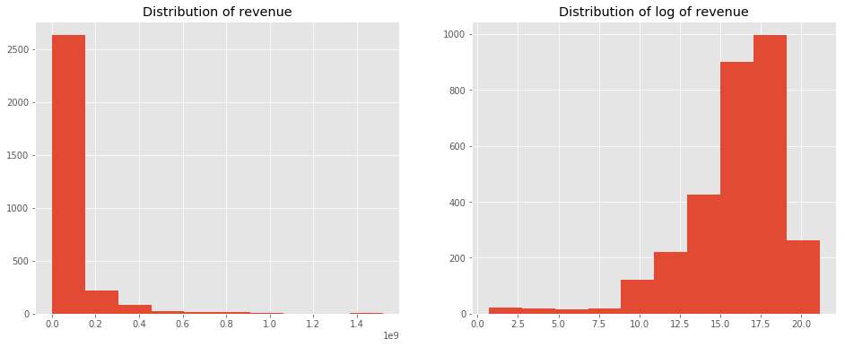

```python
fig, ax = plt.subplots(figsize = (16, 6))
plt.subplot(1, 2, 1)
plt.hist(train['revenue']);
plt.title('Distribution of revenue');
plt.subplot(1, 2, 2)
plt.hist(np.log1p(train['revenue']));
plt.title('Distribution of log of revenue');
```

```python
train['log_revenue'] = np.log1p(train['revenue'])
```

As we can see revenue distribution has a high skewness! It is better to use `np.log1p` of revenue.

### Budget

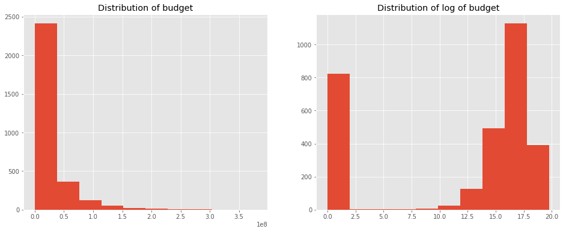

```python
fig, ax = plt.subplots(figsize = (16, 6))
plt.subplot(1, 2, 1)
plt.hist(train['budget']);
plt.title('Distribution of budget');
plt.subplot(1, 2, 2)
plt.hist(np.log1p(train['budget']));
plt.title('Distribution of log of budget');
```

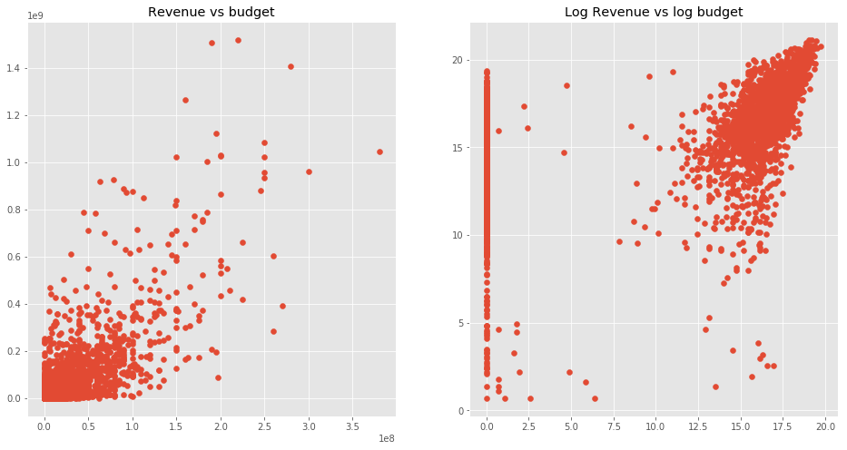

```python
plt.figure(figsize=(16, 8))
plt.subplot(1, 2, 1)
plt.scatter(train['budget'], train['revenue'])
plt.title('Revenue vs budget');
plt.subplot(1, 2, 2)
plt.scatter(np.log1p(train['budget']), train['log_revenue'])
plt.title('Log Revenue vs log budget');
```

Budget and revenue are somewhat correlated

```python
train['log_budget'] = np.log1p(train['budget'])
test['log_budget'] = np.log1p(test['budget'])
```

### homepage

```python
train['homepage'].value_counts().head()
```

```
http://www.transformersmovie.com/    4
http://www.lordoftherings.net/       2
http://www.thehobbit.com/            2
http://www.gruz200.ru/main/          1
http://www.historyx.com/             1
Name: homepage, dtype: int64
```

Most of homepages are unique, so this feature may be useless.

```python
train['has_homepage'] = 0
train.loc[train['homepage'].isnull() == False, 'has_homepage'] = 1
test['has_homepage'] = 0
test.loc[test['homepage'].isnull() == False, 'has_homepage'] = 1
```

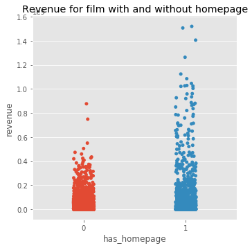

```python
sns.catplot(x='has_homepage', y='revenue', data=train);
plt.title('Revenue for film with and without homepage');
```

Films with homepage tend to generate more revenue! I suppose people can know more about the film thanks to homepage.

### original_language

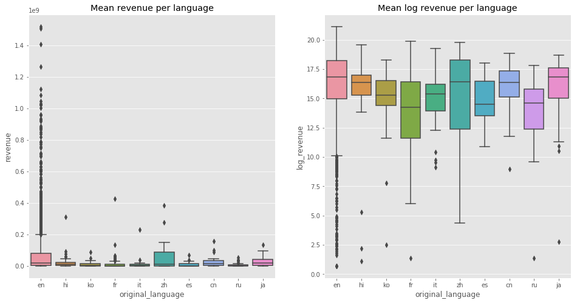

```python
plt.figure(figsize=(16, 8))
plt.subplot(1, 2, 1)
sns.boxplot(x='original_language', y='revenue', data=train.loc[train['original_language'].isin(train['original_language'].value_counts().head(10).index)]);
plt.title('Mean revenue per language');
plt.subplot(1, 2, 2)
sns.boxplot(x='original_language', y='log_revenue', data=train.loc[train['original_language'].isin(train['original_language'].value_counts().head(10).index)]);
plt.title('Mean log revenue per language');
```

As we know there are much more english films and they have a higher range of values. Films with the highest revenue are usually in English, but there are also high revenue films in other languages.

### Words that have impact on revenues (using stopwords and ELI5)

```python
vectorizer = TfidfVectorizer(
            sublinear_tf=True,
            analyzer='word',
            token_pattern=r'\w{1,}',
            ngram_range=(1, 2),
            min_df=5)

overview_text = vectorizer.fit_transform(train['overview'].fillna(''))
linreg = LinearRegression()
linreg.fit(overview_text, train['log_revenue'])
eli5.show_weights(linreg, vec=vectorizer, top=20, feature_filter=lambda x: x != '<BIAS>')
```

**y** top features

| Weight<sup>?</sup> | Feature |
| --- | --- |
| +10.086 | bombing |
| +9.263 | complications |
| *… 3742 more positive …* |  |
| *… 3431 more negative …* |  |
| -9.170 | critic |
| -9.195 | status |
| -9.329 | 18 |
| -9.356 | politicians |
| -9.456 | life they |
| -9.752 | violence |
| -9.860 | she will |
| -9.864 | who also |
| -10.199 | casino |
| -10.261 | escape and |
| -10.427 | receiving |
| -10.646 | kept |
| -10.653 | attracted to |
| -10.835 | sally |
| -11.791 | and be |
| -12.290 | campaign |
| -13.815 | mike |
| -15.395 | woman from |

```python
print('Target value:', train['log_revenue'][1000])
eli5.show_prediction(linreg, doc=train['overview'].values[1000], vec=vectorizer)
```

```
Target value: 16.44583954907521
```

**y** (score **16.446**) top features

| Contribution<sup>?</sup> | Feature |
| --- | --- |
| +15.962 | <BIAS> |
| +0.484 | Highlighted in text (sum) |

when elizabeth returns to her mother's home after her marriage breaks up, she recreates her imaginary childhood friend, fred, to escape from the trauma of losing her husband and her job. in between the chaos and mayhem that fred creates, elizabeth attempts to win back her husband and return to normality.

We can see that some words can be used to predict revenue, but we will need more that overview text to build a good model.

#### Popularity metrics

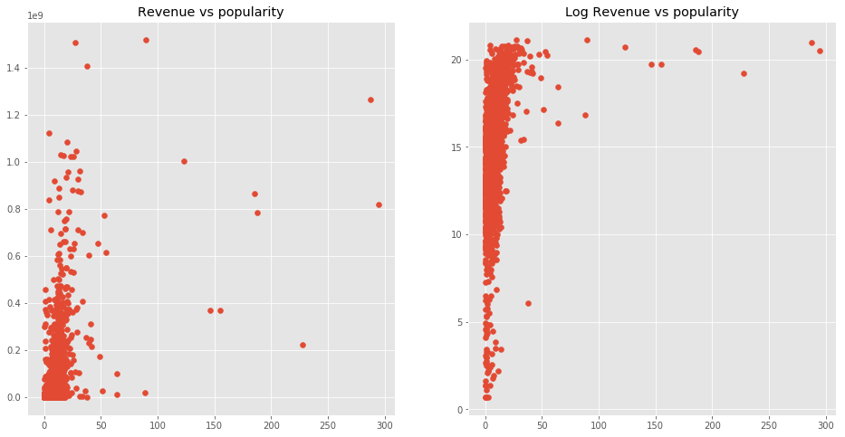

```python
plt.figure(figsize=(16, 8))
plt.subplot(1, 2, 1)
plt.scatter(train['popularity'], train['revenue'])
plt.title('Revenue vs popularity');
plt.subplot(1, 2, 2)
plt.scatter(train['popularity'], train['log_revenue'])
plt.title('Log Revenue vs popularity');
```

### release_date

```python
test.loc[test['release_date'].isnull() == True, 'release_date'] = '01/01/98'
```

```python
def fix_date(x):
    """
    Fixes dates which are in 20xx
    """
    year = x.split('/')[2]
    if int(year) <= 19:
        return x[:-2] + '20' + year
    else:
        return x[:-2] + '19' + year
```

```python
train['release_date'] = train['release_date'].apply(lambda x: fix_date(x))
test['release_date'] = test['release_date'].apply(lambda x: fix_date(x))
train['release_date'] = pd.to_datetime(train['release_date'])
test['release_date'] = pd.to_datetime(test['release_date'])
```

```python
# creating features based on dates
def process_date(df):
    date_parts = ["year", "weekday", "month", 'weekofyear', 'day', 'quarter']
    for part in date_parts:
        part_col = 'release_date' + "_" + part
        df[part_col] = getattr(df['release_date'].dt, part).astype(int)

    return df

train = process_date(train)
test = process_date(test)
```

```python
d1 = train['release_date_year'].value_counts().sort_index()
d2 = test['release_date_year'].value_counts().sort_index()
data = [go.Scatter(x=d1.index, y=d1.values, name='train'), go.Scatter(x=d2.index, y=d2.values, name='test')]
layout = go.Layout(dict(title = "Number of films per year",
                  xaxis = dict(title = 'Year'),
                  yaxis = dict(title = 'Count'),
                  ),legend=dict(
                orientation="v"))
py.iplot(dict(data=data, layout=layout))
```

[interactive chart not shown]

```python
d1 = train['release_date_year'].value_counts().sort_index()
d2 = train.groupby(['release_date_year'])['revenue'].sum()
data = [go.Scatter(x=d1.index, y=d1.values, name='film count'), go.Scatter(x=d2.index, y=d2.values, name='total revenue', yaxis='y2')]
layout = go.Layout(dict(title = "Number of films and total revenue per year",
                  xaxis = dict(title = 'Year'),
                  yaxis = dict(title = 'Count'),
                  yaxis2=dict(title='Total revenue', overlaying='y', side='right')
                  ),legend=dict(
                orientation="v"))
py.iplot(dict(data=data, layout=layout))
```

[interactive chart not shown]

```python
d1 = train['release_date_year'].value_counts().sort_index()
d2 = train.groupby(['release_date_year'])['revenue'].mean()
data = [go.Scatter(x=d1.index, y=d1.values, name='film count'), go.Scatter(x=d2.index, y=d2.values, name='mean revenue', yaxis='y2')]
layout = go.Layout(dict(title = "Number of films and average revenue per year",
                  xaxis = dict(title = 'Year'),
                  yaxis = dict(title = 'Count'),
                  yaxis2=dict(title='Average revenue', overlaying='y', side='right')
                  ),legend=dict(
                orientation="v"))
py.iplot(dict(data=data, layout=layout))
```

[interactive chart not shown]

We can see that number of films and total revenue are growing, which is to be expected. But there were some years in the past with a high number of successful films, which brought high revenue.

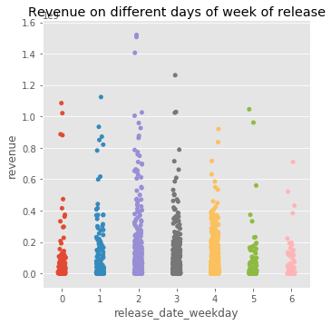

```python
sns.catplot(x='release_date_weekday', y='revenue', data=train);
plt.title('Revenue on different days of week of release');
```

Surprisingly films releases on Wednesdays and on Thursdays tend to have a higher revenue.

### runtime

The length of the film in minutes

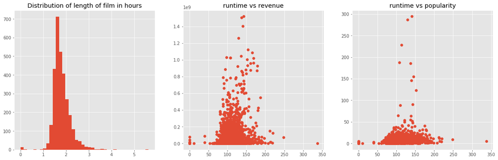

```python
plt.figure(figsize=(20, 6))
plt.subplot(1, 3, 1)
plt.hist(train['runtime'].fillna(0) / 60, bins=40);
plt.title('Distribution of length of film in hours');
plt.subplot(1, 3, 2)
plt.scatter(train['runtime'].fillna(0), train['revenue'])
plt.title('runtime vs revenue');
plt.subplot(1, 3, 3)
plt.scatter(train['runtime'].fillna(0), train['popularity'])
plt.title('runtime vs popularity');
```

### Status

```python
train['status'].value_counts()
```

```
Released    2996
Rumored        4
Name: status, dtype: int64
```

```python
test['status'].value_counts()
```

```
Released           4389
Post Production       5
Rumored               2
Name: status, dtype: int64
```

AS we can see only 4 films in train data and 7 in test aren't released yet, so this feature is quite useless.

### Collections

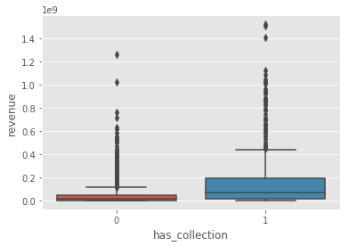

```python
sns.boxplot(x='has_collection', y='revenue', data=train);
```

Films, which are part of a collection usually have higher revenues. I suppose such films have a bigger fan base thanks to previous films.

### Genres

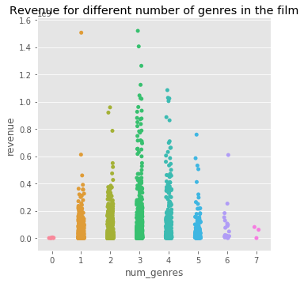

```python
sns.catplot(x='num_genres', y='revenue', data=train);
plt.title('Revenue for different number of genres in the film');
```

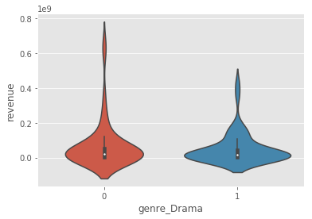

```python
sns.violinplot(x='genre_Drama', y='revenue', data=train[:100]);
```

Some genres tend to have less revenue, some tend to have higher.

### Production countries

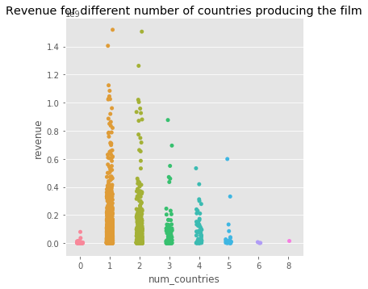

```python
sns.catplot(x='num_countries', y='revenue', data=train);
plt.title('Revenue for different number of countries producing the film');
```

## Modelling and feature generation

```python
train = train.drop(['homepage', 'imdb_id', 'poster_path', 'release_date', 'status', 'log_revenue'], axis=1)
test = test.drop(['homepage', 'imdb_id', 'poster_path', 'release_date', 'status'], axis=1)
```

```python
for col in train.columns:
    if train[col].nunique() == 1:
        print(col)
        train = train.drop([col], axis=1)
        test = test.drop([col], axis=1)
```

```
language_
cast_character_
```

```python
for col in ['original_language', 'collection_name', 'all_genres']:
    le = LabelEncoder()
    le.fit(list(train[col].fillna('')) + list(test[col].fillna('')))
    train[col] = le.transform(train[col].fillna('').astype(str))
    test[col] = le.transform(test[col].fillna('').astype(str))
```

```python
train_texts = train[['title', 'tagline', 'overview', 'original_title']]
test_texts = test[['title', 'tagline', 'overview', 'original_title']]
```

```python
for col in ['title', 'tagline', 'overview', 'original_title']:
    train['len_' + col] = train[col].fillna('').apply(lambda x: len(str(x)))
    train['words_' + col] = train[col].fillna('').apply(lambda x: len(str(x.split(' '))))
    train = train.drop(col, axis=1)
    test['len_' + col] = test[col].fillna('').apply(lambda x: len(str(x)))
    test['words_' + col] = test[col].fillna('').apply(lambda x: len(str(x.split(' '))))
    test = test.drop(col, axis=1)
```

#### Credits for the training list below goes to https://www.kaggle.com/artgor/eda-feature-engineering-and-model-interpretation

```python
train.loc[train['id'] == 16,'revenue'] = 192864          # Skinning
train.loc[train['id'] == 90,'budget'] = 30000000         # Sommersby
train.loc[train['id'] == 118,'budget'] = 60000000        # Wild Hogs
train.loc[train['id'] == 149,'budget'] = 18000000        # Beethoven
train.loc[train['id'] == 313,'revenue'] = 12000000       # The Cookout
train.loc[train['id'] == 451,'revenue'] = 12000000       # Chasing Liberty
train.loc[train['id'] == 464,'budget'] = 20000000        # Parenthood
train.loc[train['id'] == 470,'budget'] = 13000000        # The Karate Kid, Part II
train.loc[train['id'] == 513,'budget'] = 930000          # From Prada to Nada
train.loc[train['id'] == 797,'budget'] = 8000000         # Welcome to Dongmakgol
train.loc[train['id'] == 819,'budget'] = 90000000        # Alvin and the Chipmunks: The Road Chip
train.loc[train['id'] == 850,'budget'] = 90000000        # Modern Times
train.loc[train['id'] == 1112,'budget'] = 7500000        # An Officer and a Gentleman
train.loc[train['id'] == 1131,'budget'] = 4300000        # Smokey and the Bandit
train.loc[train['id'] == 1359,'budget'] = 10000000       # Stir Crazy
train.loc[train['id'] == 1542,'budget'] = 1              # All at Once
train.loc[train['id'] == 1570,'budget'] = 15800000       # Crocodile Dundee II
train.loc[train['id'] == 1571,'budget'] = 4000000        # Lady and the Tramp
train.loc[train['id'] == 1714,'budget'] = 46000000       # The Recruit
train.loc[train['id'] == 1721,'budget'] = 17500000       # Cocoon
train.loc[train['id'] == 1865,'revenue'] = 25000000      # Scooby-Doo 2: Monsters Unleashed
train.loc[train['id'] == 2268,'budget'] = 17500000       # Madea Goes to Jail budget
train.loc[train['id'] == 2491,'revenue'] = 6800000       # Never Talk to Strangers
train.loc[train['id'] == 2602,'budget'] = 31000000       # Mr. Holland's Opus
train.loc[train['id'] == 2612,'budget'] = 15000000       # Field of Dreams
train.loc[train['id'] == 2696,'budget'] = 10000000       # Nurse 3-D
train.loc[train['id'] == 2801,'budget'] = 10000000       # Fracture
test.loc[test['id'] == 3889,'budget'] = 15000000       # Colossal
test.loc[test['id'] == 6733,'budget'] = 5000000        # The Big Sick
test.loc[test['id'] == 3197,'budget'] = 8000000        # High-Rise
test.loc[test['id'] == 6683,'budget'] = 50000000       # The Pink Panther 2
test.loc[test['id'] == 5704,'budget'] = 4300000        # French Connection II
test.loc[test['id'] == 6109,'budget'] = 281756         # Dogtooth
test.loc[test['id'] == 7242,'budget'] = 10000000       # Addams Family Values
test.loc[test['id'] == 7021,'budget'] = 17540562       #  Two Is a Family
test.loc[test['id'] == 5591,'budget'] = 4000000        # The Orphanage
test.loc[test['id'] == 4282,'budget'] = 20000000       # Big Top Pee-wee

power_six = train.id[train.budget > 1000][train.revenue < 100]

for k in power_six :
    train.loc[train['id'] == k,'revenue'] =  train.loc[train['id'] == k,'revenue'] * 1000000
```

```python
X = train.drop(['id', 'revenue'], axis=1)
y = np.log1p(train['revenue'])
X_test = test.drop(['id'], axis=1)
```

```python
X_train, X_valid, y_train, y_valid = train_test_split(X, y, test_size=0.1)
```

```
     'min_data_in_leaf': 20,
     'objective': 'regression',
     'max_depth': 5,
     'learning_rate': 0.01,
     "boosting": "gbdt",
     "feature_fraction": 0.9,
     "bagging_freq": 1,
     "bagging_fraction": 0.9,
     "bagging_seed": 3472,
     "metric": 'rmse',
     "lambda_l1": 0.2,
     "verbosity": -1}
```

```python
eli5.show_weights(model1, feature_filter=lambda x: x != '<BIAS>')
```

| Weight | Feature |
| --- | --- |
| 0.4391 | budget |
| 0.1167 | popularity |
| 0.0638 | release_date_year |
| 0.0619 | log_budget |
| 0.0242 | runtime |
| 0.0196 | genders_2_crew |
| 0.0150 | all_genres |
| 0.0133 | release_date_day |
| 0.0124 | collection_name |
| 0.0108 | release_date_weekofyear |
| 0.0098 | num_Keywords |
| 0.0097 | genders_1_cast |
| 0.0095 | language_English |
| 0.0094 | num_cast |
| 0.0085 | genders_2_cast |
| 0.0078 | release_date_weekday |
| 0.0074 | genders_0_crew |
| 0.0070 | words_title |
| 0.0067 | num_crew |
| 0.0066 | words_original_title |
| *… 216 more …* |  |

```python
n_fold = 5
folds = KFold(n_splits=n_fold, shuffle=True, random_state=42)
```

```python
def train_model(X, X_test, y, params=None, folds=folds, model_type='lgb', plot_feature_importance=False, model=None):

    oof = np.zeros(X.shape[0])
    prediction = np.zeros(X_test.shape[0])
    scores = []
    feature_importance = pd.DataFrame()
    for fold_n, (train_index, valid_index) in enumerate(folds.split(X)):
        print('Fold', fold_n, 'started at', time.ctime())
        if model_type == 'sklearn':
            X_train, X_valid = X[train_index], X[valid_index]
        else:
            X_train, X_valid = X.values[train_index], X.values[valid_index]
        y_train, y_valid = y[train_index], y[valid_index]

        if model_type == 'lgb':
            model = lgb.LGBMRegressor(**params, n_estimators = 20000, nthread = 4, n_jobs = -1)
            model.fit(X_train, y_train,
                    eval_set=[(X_train, y_train), (X_valid, y_valid)], eval_metric='rmse',
                    verbose=1000, early_stopping_rounds=200)

            y_pred_valid = model.predict(X_valid)
            y_pred = model.predict(X_test, num_iteration=model.best_iteration_)

        if model_type == 'xgb':
            train_data = xgb.DMatrix(data=X_train, label=y_train)
            valid_data = xgb.DMatrix(data=X_valid, label=y_valid)

            watchlist = [(train_data, 'train'), (valid_data, 'valid_data')]
            model = xgb.train(dtrain=train_data, num_boost_round=20000, evals=watchlist, early_stopping_rounds=200, verbose_eval=500, params=params)
            y_pred_valid = model.predict(xgb.DMatrix(X_valid), ntree_limit=model.best_ntree_limit)
            y_pred = model.predict(xgb.DMatrix(X_test.values), ntree_limit=model.best_ntree_limit)

        if model_type == 'sklearn':
            model = model
            model.fit(X_train, y_train)
            y_pred_valid = model.predict(X_valid).reshape(-1,)
            score = mean_squared_error(y_valid, y_pred_valid)

            y_pred = model.predict(X_test)

        if model_type == 'cat':
            model = CatBoostRegressor(iterations=20000,  eval_metric='RMSE', **params)
            model.fit(X_train, y_train, eval_set=(X_valid, y_valid), cat_features=[], use_best_model=True, verbose=False)

            y_pred_valid = model.predict(X_valid)
            y_pred = model.predict(X_test)

        oof[valid_index] = y_pred_valid.reshape(-1,)
        scores.append(mean_squared_error(y_valid, y_pred_valid) ** 0.5)

        prediction += y_pred

        if model_type == 'lgb':
            # feature importance
            fold_importance = pd.DataFrame()
            fold_importance["feature"] = X.columns
            fold_importance["importance"] = model.feature_importances_
            fold_importance["fold"] = fold_n + 1
            feature_importance = pd.concat([feature_importance, fold_importance], axis=0)

    prediction /= n_fold

    print('CV mean score: {0:.4f}, std: {1:.4f}.'.format(np.mean(scores), np.std(scores)))

    if model_type == 'lgb':
        feature_importance["importance"] /= n_fold
        if plot_feature_importance:
            cols = feature_importance[["feature", "importance"]].groupby("feature").mean().sort_values(
                by="importance", ascending=False)[:50].index

            best_features = feature_importance.loc[feature_importance.feature.isin(cols)]

            plt.figure(figsize=(16, 12));
            sns.barplot(x="importance", y="feature", data=best_features.sort_values(by="importance", ascending=False));
            plt.title('LGB Features (avg over folds)');

            return oof, prediction, feature_importance
        return oof, prediction

    else:
        return oof, prediction
```

```
Fold 0 started at Fri May  3 16:02:37 2019
Training until validation scores don't improve for 200 rounds.
[1000]	training's rmse: 1.14843	valid_1's rmse: 1.84665
Early stopping, best iteration is:
[1100]	training's rmse: 1.10735	valid_1's rmse: 1.84514
Fold 1 started at Fri May  3 16:02:42 2019
Training until validation scores don't improve for 200 rounds.
[1000]	training's rmse: 1.18138	valid_1's rmse: 1.78116
[2000]	training's rmse: 0.859822	valid_1's rmse: 1.76397
Early stopping, best iteration is:
[2356]	training's rmse: 0.768384	valid_1's rmse: 1.76033
Fold 2 started at Fri May  3 16:02:51 2019
Training until validation scores don't improve for 200 rounds.
Early stopping, best iteration is:
[728]	training's rmse: 1.31148	valid_1's rmse: 1.76566
Fold 3 started at Fri May  3 16:02:55 2019
Training until validation scores don't improve for 200 rounds.
[1000]	training's rmse: 1.11872	valid_1's rmse: 2.23665
Early stopping, best iteration is:
[1185]	training's rmse: 1.04797	valid_1's rmse: 2.22704
Fold 4 started at Fri May  3 16:02:59 2019
Training until validation scores don't improve for 200 rounds.
Early stopping, best iteration is:
[462]	training's rmse: 1.39567	valid_1's rmse: 2.07969
CV mean score: 1.9356, std: 0.1863.
```

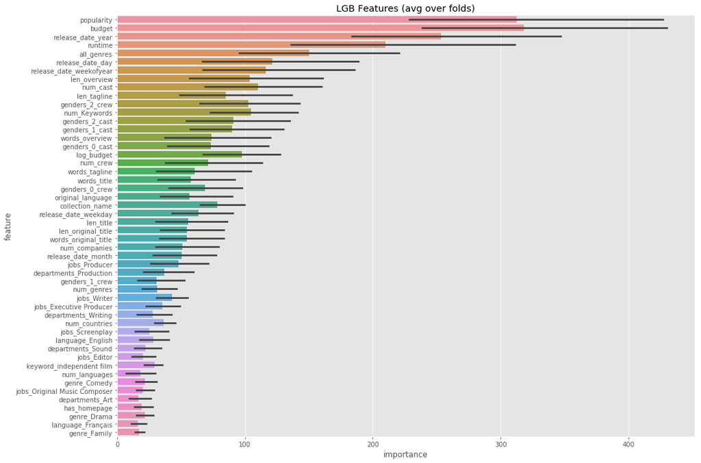

```python
params = {'num_leaves': 30,
         'min_data_in_leaf': 10,
         'objective': 'regression',
         'max_depth': 5,
         'learning_rate': 0.01,
         "boosting": "gbdt",
         "feature_fraction": 0.9,
         "bagging_freq": 1,
         "bagging_fraction": 0.9,
         "bagging_seed": 3472,
         "metric": 'rmse',
         "lambda_l1": 0.2,
         "verbosity": -1}
oof_lgb, prediction_lgb, _ = train_model(X, X_test, y, params=params, model_type='lgb', plot_feature_importance=True)
```

### OOF features based on texts

```python
for col in train_texts.columns:
    vectorizer = TfidfVectorizer(
                sublinear_tf=True,
                analyzer='word',
                token_pattern=r'\w{1,}',
                ngram_range=(1, 2),
                min_df=10
    )
    vectorizer.fit(list(train_texts[col].fillna('')) + list(test_texts[col].fillna('')))
    train_col_text = vectorizer.transform(train_texts[col].fillna(''))
    test_col_text = vectorizer.transform(test_texts[col].fillna(''))
    model = linear_model.RidgeCV(alphas=(0.01, 0.1, 1.0, 10.0, 100.0), scoring='neg_mean_squared_error', cv=folds)
    oof_text, prediction_text = train_model(train_col_text, test_col_text, y, params=None, model_type='sklearn', model=model)

    X[col + '_oof'] = oof_text
    X_test[col + '_oof'] = prediction_text
```

```
Fold 0 started at Fri May  3 16:03:23 2019
Fold 1 started at Fri May  3 16:03:23 2019
Fold 2 started at Fri May  3 16:03:24 2019
Fold 3 started at Fri May  3 16:03:25 2019
Fold 4 started at Fri May  3 16:03:25 2019
CV mean score: 2.9749, std: 0.1645.
Fold 0 started at Fri May  3 16:03:27 2019
Fold 1 started at Fri May  3 16:03:28 2019
Fold 2 started at Fri May  3 16:03:29 2019
Fold 3 started at Fri May  3 16:03:30 2019
Fold 4 started at Fri May  3 16:03:32 2019
CV mean score: 2.8881, std: 0.1368.
Fold 0 started at Fri May  3 16:03:37 2019
Fold 1 started at Fri May  3 16:03:41 2019
Fold 2 started at Fri May  3 16:03:43 2019
Fold 3 started at Fri May  3 16:03:47 2019
Fold 4 started at Fri May  3 16:03:49 2019
CV mean score: 2.9421, std: 0.1462.
Fold 0 started at Fri May  3 16:03:53 2019
Fold 1 started at Fri May  3 16:03:54 2019
Fold 2 started at Fri May  3 16:03:54 2019
Fold 3 started at Fri May  3 16:03:55 2019
Fold 4 started at Fri May  3 16:03:55 2019
CV mean score: 2.9584, std: 0.1616.
```

### Further Feature Generation

```python
X.head()
```

|  | budget | original_language | popularity | runtime | collection_name | has_collection | num_genres | all_genres | genre_Drama | genre_Comedy | genre_Thriller | genre_Action | genre_Romance | genre_Crime | genre_Adventure | genre_Horror | genre_Science Fiction | genre_Family | genre_Fantasy | genre_Mystery | genre_Animation | genre_History | genre_Music | num_companies | production_company_Warner Bros. | production_company_Universal Pictures | production_company_Paramount Pictures | production_company_Twentieth Century Fox Film Corporation | production_company_Columbia Pictures | … |
| --- | --- | --- | --- | --- | --- | --- | --- | --- | --- | --- | --- | --- | --- | --- | --- | --- | --- | --- | --- | --- | --- | --- | --- | --- | --- | --- | --- | --- | --- | --- |
| 0 | 14000000 | 10 | 6.575393 | 93.0 | 282 | 1 | 1 | 480 | 0 | 1 | 0 | 0 | 0 | 0 | 0 | 0 | 0 | 0 | 0 | 0 | 0 | 0 | 0 | 3 | 0 | 0 | 1 | 0 | 0 | … |
| 1 | 40000000 | 10 | 8.248895 | 113.0 | 641 | 1 | 4 | 516 | 1 | 1 | 0 | 0 | 1 | 0 | 0 | 0 | 0 | 1 | 0 | 0 | 0 | 0 | 0 | 1 | 0 | 0 | 0 | 0 | 0 | … |
| 2 | 3300000 | 10 | 64.299990 | 105.0 | 1 | 0 | 1 | 658 | 1 | 0 | 0 | 0 | 0 | 0 | 0 | 0 | 0 | 0 | 0 | 0 | 0 | 0 | 0 | 3 | 0 | 0 | 0 | 0 | 0 | … |
| 3 | 1200000 | 16 | 3.174936 | 122.0 | 1 | 0 | 2 | 742 | 1 | 0 | 1 | 0 | 0 | 0 | 0 | 0 | 0 | 0 | 0 | 0 | 0 | 0 | 0 | 0 | 0 | 0 | 0 | 0 | 0 | … |
| 4 | 0 | 24 | 1.148070 | 118.0 | 1 | 0 | 2 | 295 | 0 | 0 | 1 | 1 | 0 | 0 | 0 | 0 | 0 | 0 | 0 | 0 | 0 | 0 | 0 | 0 | 0 | 0 | 0 | 0 | 0 | … |

```python
def new_features(df):
    df['budget_to_popularity'] = df['budget'] / df['popularity']
    df['budget_to_runtime'] = df['budget'] / df['runtime']

    # some features from https://www.kaggle.com/somang1418/happy-valentines-day-and-keep-kaggling-3
    df['_budget_year_ratio'] = df['budget'] / (df['release_date_year'] * df['release_date_year'])
    df['_releaseYear_popularity_ratio'] = df['release_date_year'] / df['popularity']
    df['_releaseYear_popularity_ratio2'] = df['popularity'] / df['release_date_year']

    df['runtime_to_mean_year'] = df['runtime'] / df.groupby("release_date_year")["runtime"].transform('mean')
    df['popularity_to_mean_year'] = df['popularity'] / df.groupby("release_date_year")["popularity"].transform('mean')
    df['budget_to_mean_year'] = df['budget'] / df.groupby("release_date_year")["budget"].transform('mean')

    return df
```

```python
X = new_features(X)
X_test = new_features(X_test)
```

```
Fold 0 started at Fri May  3 16:05:01 2019
Training until validation scores don't improve for 200 rounds.
[1000]	training's rmse: 1.09702	valid_1's rmse: 1.85681
Early stopping, best iteration is:
[1115]	training's rmse: 1.05021	valid_1's rmse: 1.85374
Fold 1 started at Fri May  3 16:05:10 2019
Training until validation scores don't improve for 200 rounds.
[1000]	training's rmse: 1.12833	valid_1's rmse: 1.79515
Early stopping, best iteration is:
[1659]	training's rmse: 0.878481	valid_1's rmse: 1.77767
Fold 2 started at Fri May  3 16:05:22 2019
Training until validation scores don't improve for 200 rounds.
[1000]	training's rmse: 1.15006	valid_1's rmse: 1.78756
Early stopping, best iteration is:
[921]	training's rmse: 1.18609	valid_1's rmse: 1.78536
Fold 3 started at Fri May  3 16:05:27 2019
Training until validation scores don't improve for 200 rounds.
[1000]	training's rmse: 1.06439	valid_1's rmse: 2.23398
[2000]	training's rmse: 0.752669	valid_1's rmse: 2.22026
Early stopping, best iteration is:
[2082]	training's rmse: 0.733776	valid_1's rmse: 2.21938
Fold 4 started at Fri May  3 16:05:38 2019
Training until validation scores don't improve for 200 rounds.
Early stopping, best iteration is:
[490]	training's rmse: 1.35761	valid_1's rmse: 2.07514
CV mean score: 1.9423, std: 0.1755.
```

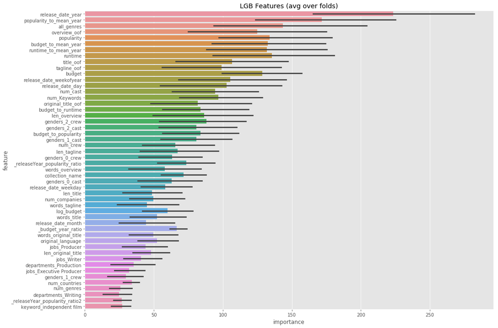

```python
oof_lgb, prediction_lgb, _ = train_model(X, X_test, y, params=params, model_type='lgb', plot_feature_importance=True)
```

### Important features

Let's have a look at important features using ELI5 and SHAP!

```python
X_train, X_valid, y_train, y_valid = train_test_split(X, y, test_size=0.1)

params = {'num_leaves': 30,
         'min_data_in_leaf': 20,
         'objective': 'regression',
         'max_depth': 6,
         'learning_rate': 0.01,
         "boosting": "gbdt",
         "feature_fraction": 0.9,
         "bagging_freq": 1,
         "bagging_fraction": 0.9,
         "bagging_seed": 3472,
         "metric": 'rmse',
         "lambda_l1": 0.2,
         "verbosity": -1}
model1 = lgb.LGBMRegressor(**params, n_estimators = 20000, nthread = 4, n_jobs = -1)
model1.fit(X_train, y_train,
        eval_set=[(X_train, y_train), (X_valid, y_valid)], eval_metric='rmse',
        verbose=1000, early_stopping_rounds=200)

eli5.show_weights(model1, feature_filter=lambda x: x != '<BIAS>')
```

```
Training until validation scores don't improve for 200 rounds.
Early stopping, best iteration is:
[751]	training's rmse: 1.21229	valid_1's rmse: 1.89449
```

| Weight | Feature |
| --- | --- |
| 0.2623 | _budget_year_ratio |
| 0.1453 | budget_to_mean_year |
| 0.0646 | popularity_to_mean_year |
| 0.0613 | budget |
| 0.0518 | release_date_year |
| 0.0226 | _releaseYear_popularity_ratio |
| 0.0199 | budget_to_runtime |
| 0.0198 | popularity |
| 0.0183 | runtime_to_mean_year |
| 0.0171 | runtime |
| 0.0162 | all_genres |
| 0.0137 | release_date_day |
| 0.0127 | genders_2_crew |
| 0.0120 | _releaseYear_popularity_ratio2 |
| 0.0116 | collection_name |
| 0.0098 | overview_oof |
| 0.0092 | num_Keywords |
| 0.0092 | log_budget |
| 0.0087 | genders_1_cast |
| 0.0086 | genders_2_cast |
| *… 228 more …* |  |

[output not shown]

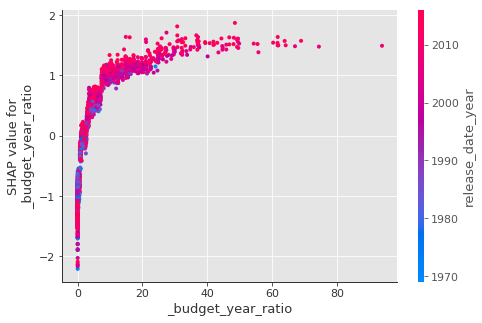

[output not shown]

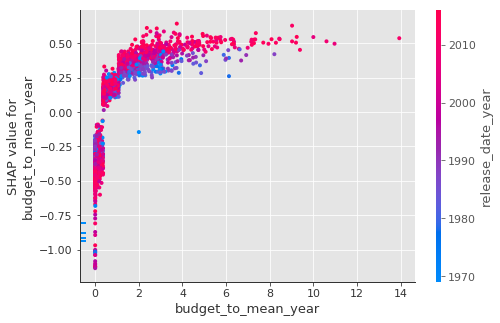

[output not shown]

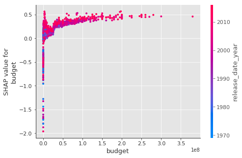

[output not shown]

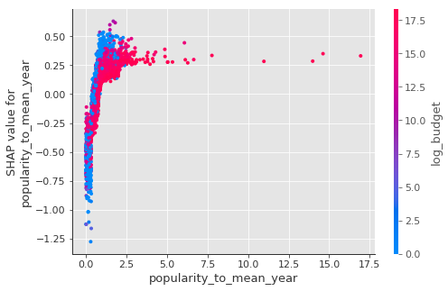

[output not shown]

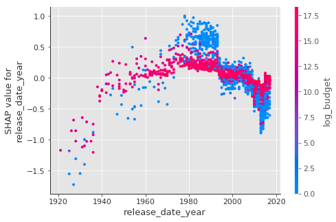

[output not shown]

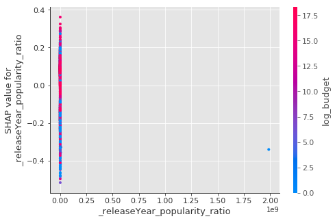

[output not shown]

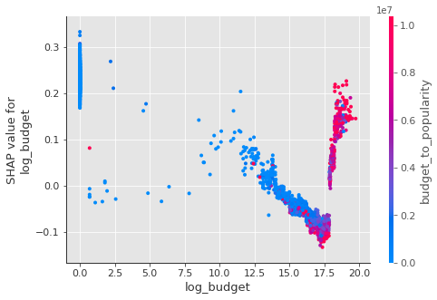

[output not shown]

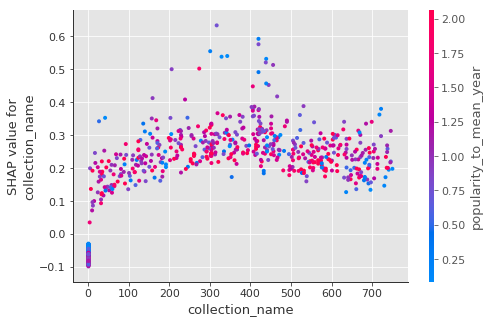

[output not shown]

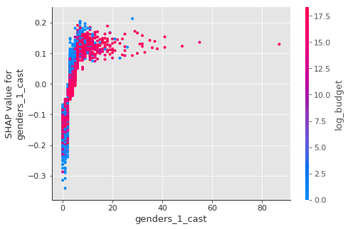

[output not shown]

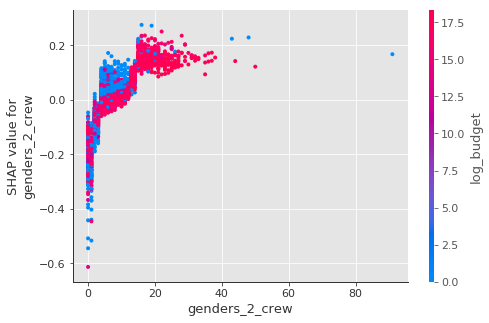

```python
top_cols = X_train.columns[np.argsort(shap_values.std(0))[::-1]][:10]
for col in top_cols:
    shap.dependence_plot(col, shap_values, X_train)
```

Here we can see interactions between important features. There are some interesting things here. For example relationship between release_date_year and log_budget. Up to ~1990 low budget films brought higher revenues, but after 2000 year high budgets tended to be correlated with higher revenues. And in genereal the effect of budget diminished.

Let's create new features as interactions between top important features. Some of them make little sense, but maybe they could improve the model.

```python
def top_cols_interaction(df):
    df['budget_to_year'] = df['budget'] / df['release_date_year']
    df['budget_to_mean_year_to_year'] = df['budget_to_mean_year'] / df['release_date_year']
    df['popularity_to_mean_year_to_log_budget'] = df['popularity_to_mean_year'] / df['log_budget']
    df['year_to_log_budget'] = df['release_date_year'] / df['log_budget']
    df['budget_to_runtime_to_year'] = df['budget_to_runtime'] / df['release_date_year']
    df['genders_1_cast_to_log_budget'] = df['genders_1_cast'] / df['log_budget']
    df['all_genres_to_popularity_to_mean_year'] = df['all_genres'] / df['popularity_to_mean_year']
    df['genders_2_crew_to_budget_to_mean_year'] = df['genders_2_crew'] / df['budget_to_mean_year']
    df['overview_oof_to_genders_2_crew'] = df['overview_oof'] / df['genders_2_crew']

    return df
```

```python
X = top_cols_interaction(X)
X_test = top_cols_interaction(X_test)
```

```python
X = X.replace([np.inf, -np.inf], 0).fillna(0)
X_test = X_test.replace([np.inf, -np.inf], 0).fillna(0)
```

### External features

Credits for ideation go to https://www.kaggle.com/madengr00/pre-process-gradient-boosting-w-residual-plots

```python
trainAdditionalFeatures = pd.read_csv('TrainAdditionalFeatures.csv')
testAdditionalFeatures = pd.read_csv('TestAdditionalFeatures.csv')

train = pd.read_csv('train.csv')
test = pd.read_csv('test.csv')
X['imdb_id'] = train['imdb_id']
X_test['imdb_id'] = test['imdb_id']
del train, test

X = pd.merge(X, trainAdditionalFeatures, how='left', on=['imdb_id'])
X_test = pd.merge(X_test, testAdditionalFeatures, how='left', on=['imdb_id'])

X = X.drop(['imdb_id'], axis=1)
X_test = X_test.drop(['imdb_id'], axis=1)
```

```python
X.head()
```

|  | budget | original_language | popularity | runtime | collection_name | has_collection | num_genres | all_genres | genre_Drama | genre_Comedy | genre_Thriller | genre_Action | genre_Romance | genre_Crime | genre_Adventure | genre_Horror | genre_Science Fiction | genre_Family | genre_Fantasy | genre_Mystery | genre_Animation | genre_History | genre_Music | num_companies | production_company_Warner Bros. | production_company_Universal Pictures | production_company_Paramount Pictures | production_company_Twentieth Century Fox Film Corporation | production_company_Columbia Pictures | … |
| --- | --- | --- | --- | --- | --- | --- | --- | --- | --- | --- | --- | --- | --- | --- | --- | --- | --- | --- | --- | --- | --- | --- | --- | --- | --- | --- | --- | --- | --- | --- |
| 0 | 14000000 | 10 | 6.575393 | 93.0 | 282 | 1 | 1 | 480 | 0 | 1 | 0 | 0 | 0 | 0 | 0 | 0 | 0 | 0 | 0 | 0 | 0 | 0 | 0 | 3 | 0 | 0 | 1 | 0 | 0 | … |
| 1 | 40000000 | 10 | 8.248895 | 113.0 | 641 | 1 | 4 | 516 | 1 | 1 | 0 | 0 | 1 | 0 | 0 | 0 | 0 | 1 | 0 | 0 | 0 | 0 | 0 | 1 | 0 | 0 | 0 | 0 | 0 | … |
| 2 | 3300000 | 10 | 64.299990 | 105.0 | 1 | 0 | 1 | 658 | 1 | 0 | 0 | 0 | 0 | 0 | 0 | 0 | 0 | 0 | 0 | 0 | 0 | 0 | 0 | 3 | 0 | 0 | 0 | 0 | 0 | … |
| 3 | 1200000 | 16 | 3.174936 | 122.0 | 1 | 0 | 2 | 742 | 1 | 0 | 1 | 0 | 0 | 0 | 0 | 0 | 0 | 0 | 0 | 0 | 0 | 0 | 0 | 0 | 0 | 0 | 0 | 0 | 0 | … |
| 4 | 0 | 24 | 1.148070 | 118.0 | 1 | 0 | 2 | 295 | 0 | 0 | 1 | 1 | 0 | 0 | 0 | 0 | 0 | 0 | 0 | 0 | 0 | 0 | 0 | 0 | 0 | 0 | 0 | 0 | 0 | … |

```
Fold 0 started at Fri May  3 16:15:15 2019
Training until validation scores don't improve for 200 rounds.
Early stopping, best iteration is:
[564]	training's rmse: 1.0568	valid_1's rmse: 1.80932
Fold 1 started at Fri May  3 16:15:22 2019
Training until validation scores don't improve for 200 rounds.
[1000]	training's rmse: 0.759597	valid_1's rmse: 1.72764
Early stopping, best iteration is:
[838]	training's rmse: 0.859244	valid_1's rmse: 1.72648
Fold 2 started at Fri May  3 16:15:31 2019
Training until validation scores don't improve for 200 rounds.
[1000]	training's rmse: 0.760275	valid_1's rmse: 1.72078
Early stopping, best iteration is:
[988]	training's rmse: 0.76609	valid_1's rmse: 1.72053
Fold 3 started at Fri May  3 16:15:41 2019
Training until validation scores don't improve for 200 rounds.
[1000]	training's rmse: 0.744905	valid_1's rmse: 2.1643
Early stopping, best iteration is:
[1028]	training's rmse: 0.731087	valid_1's rmse: 2.16284
Fold 4 started at Fri May  3 16:15:51 2019
Training until validation scores don't improve for 200 rounds.
Early stopping, best iteration is:
[563]	training's rmse: 1.03425	valid_1's rmse: 1.95394
CV mean score: 1.8746, std: 0.1669.
```

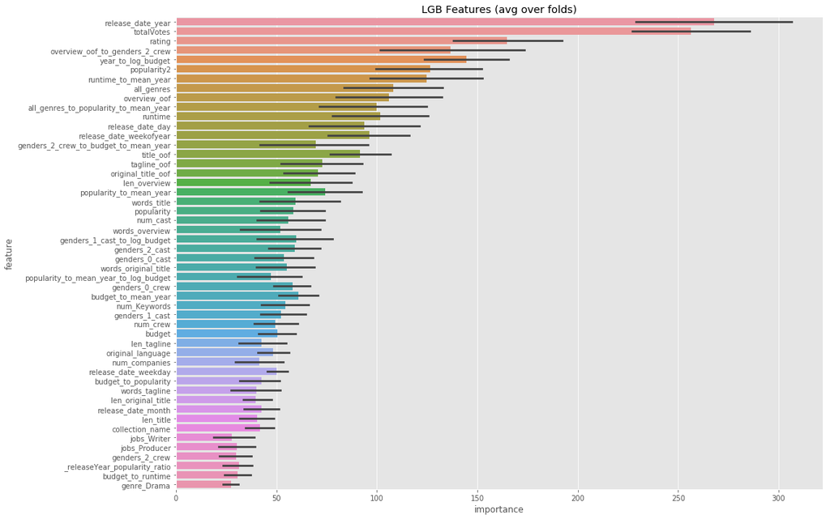

```python
params = {'num_leaves': 30,
         'min_data_in_leaf': 20,
         'objective': 'regression',
         'max_depth': 9,
         'learning_rate': 0.01,
         "boosting": "gbdt",
         "feature_fraction": 0.9,
         "bagging_freq": 1,
         "bagging_fraction": 0.9,
         "bagging_seed": 3472,
         "metric": 'rmse',
         "lambda_l1": 0.2,
         "verbosity": -1}
oof_lgb, prediction_lgb, _ = train_model(X, X_test, y, params=params, model_type='lgb', plot_feature_importance=True)
```

### Blending

```python
xgb_params = {'eta': 0.01,
              'objective': 'reg:linear',
              'max_depth': 7,
              'subsample': 0.8,
              'colsample_bytree': 0.8,
              'eval_metric': 'rmse',
              'seed': 3472,
              'silent': True}
oof_xgb, prediction_xgb = train_model(X, X_test, y, params=xgb_params, model_type='xgb', plot_feature_importance=False)
```

```
Fold 0 started at Fri May  3 16:16:45 2019
```

[output not shown]

```
Multiple eval metrics have been passed: 'valid_data-rmse' will be used for early stopping.

Will train until valid_data-rmse hasn't improved in 200 rounds.
Stopping. Best iteration:

Fold 1 started at Fri May  3 16:17:33 2019
```

[output not shown]

```
Multiple eval metrics have been passed: 'valid_data-rmse' will be used for early stopping.

Will train until valid_data-rmse hasn't improved in 200 rounds.
Stopping. Best iteration:

Fold 2 started at Fri May  3 16:18:42 2019
```

[output not shown]

```
Multiple eval metrics have been passed: 'valid_data-rmse' will be used for early stopping.

Will train until valid_data-rmse hasn't improved in 200 rounds.
Stopping. Best iteration:

Fold 3 started at Fri May  3 16:19:51 2019
```

[output not shown]

```
Multiple eval metrics have been passed: 'valid_data-rmse' will be used for early stopping.

Will train until valid_data-rmse hasn't improved in 200 rounds.
Stopping. Best iteration:

Fold 4 started at Fri May  3 16:20:43 2019
```

[output not shown]

```
Multiple eval metrics have been passed: 'valid_data-rmse' will be used for early stopping.

Will train until valid_data-rmse hasn't improved in 200 rounds.
Stopping. Best iteration:

CV mean score: 1.8510, std: 0.1616.
```

```python
cat_params = {'learning_rate': 0.002,
              'depth': 5,
              'l2_leaf_reg': 10,
              # 'bootstrap_type': 'Bernoulli',
              'colsample_bylevel': 0.8,
              'bagging_temperature': 0.2,
              #'metric_period': 500,
              'od_type': 'Iter',
              'od_wait': 100,
              'random_seed': 47,
              'allow_writing_files': False}
oof_cat, prediction_cat = train_model(X, X_test, y, params=cat_params, model_type='cat')
```

```
Fold 0 started at Fri May  3 16:22:46 2019
Fold 1 started at Fri May  3 16:27:47 2019
Fold 2 started at Fri May  3 16:42:51 2019
Fold 3 started at Fri May  3 16:53:30 2019
Fold 4 started at Fri May  3 17:10:30 2019
CV mean score: 1.8929, std: 0.1521.
```

```python
params = {'num_leaves': 30,
         'min_data_in_leaf': 20,
         'objective': 'regression',
         'max_depth': 5,
         'learning_rate': 0.01,
         "boosting": "gbdt",
         "feature_fraction": 0.9,
         "bagging_freq": 1,
         "bagging_fraction": 0.9,
         "bagging_seed": 3472,
         "metric": 'rmse',
         "lambda_l1": 0.2,
         "verbosity": -1}
oof_lgb_1, prediction_lgb_1 = train_model(X, X_test, y, params=params, model_type='lgb', plot_feature_importance=False)
```

```
Fold 0 started at Fri May  3 17:22:41 2019
Training until validation scores don't improve for 200 rounds.
Early stopping, best iteration is:
[738]	training's rmse: 1.29426	valid_1's rmse: 1.81731
Fold 1 started at Fri May  3 17:22:46 2019
Training until validation scores don't improve for 200 rounds.
[1000]	training's rmse: 1.17577	valid_1's rmse: 1.71999
Early stopping, best iteration is:
[871]	training's rmse: 1.23531	valid_1's rmse: 1.71825
Fold 2 started at Fri May  3 17:22:52 2019
Training until validation scores don't improve for 200 rounds.
[1000]	training's rmse: 1.18427	valid_1's rmse: 1.72478
Early stopping, best iteration is:
[1023]	training's rmse: 1.17502	valid_1's rmse: 1.72424
Fold 3 started at Fri May  3 17:22:58 2019
Training until validation scores don't improve for 200 rounds.
Early stopping, best iteration is:
[712]	training's rmse: 1.2472	valid_1's rmse: 2.15984
Fold 4 started at Fri May  3 17:23:02 2019
Training until validation scores don't improve for 200 rounds.
Early stopping, best iteration is:
[597]	training's rmse: 1.33128	valid_1's rmse: 1.95261
CV mean score: 1.8745, std: 0.1660.
```

```python
params = {'num_leaves': 30,
         'min_data_in_leaf': 20,
         'objective': 'regression',
         'max_depth': 7,
         'learning_rate': 0.02,
         "boosting": "gbdt",
         "feature_fraction": 0.7,
         "bagging_freq": 5,
         "bagging_fraction": 0.7,
         "bagging_seed": 3472,
         "metric": 'rmse',
         "lambda_l1": 0.2,
         "verbosity": -1}
oof_lgb_2, prediction_lgb_2 = train_model(X, X_test, y, params=params, model_type='lgb', plot_feature_importance=False)
```

```
Fold 0 started at Fri May  3 17:26:09 2019
Training until validation scores don't improve for 200 rounds.
Early stopping, best iteration is:
[522]	training's rmse: 0.946808	valid_1's rmse: 1.82648
Fold 1 started at Fri May  3 17:26:14 2019
Training until validation scores don't improve for 200 rounds.
Early stopping, best iteration is:
[348]	training's rmse: 1.14758	valid_1's rmse: 1.73997
Fold 2 started at Fri May  3 17:26:17 2019
Training until validation scores don't improve for 200 rounds.
Early stopping, best iteration is:
[468]	training's rmse: 0.992347	valid_1's rmse: 1.74403
Fold 3 started at Fri May  3 17:26:21 2019
Training until validation scores don't improve for 200 rounds.
Early stopping, best iteration is:
[415]	training's rmse: 1.00423	valid_1's rmse: 2.17883
Fold 4 started at Fri May  3 17:26:25 2019
Training until validation scores don't improve for 200 rounds.
Early stopping, best iteration is:
[345]	training's rmse: 1.11942	valid_1's rmse: 1.96205
CV mean score: 1.8903, std: 0.1652.
```

### Stacking

```python
train_stack = np.vstack([oof_lgb, oof_xgb, oof_cat, oof_lgb_1, oof_lgb_2]).transpose()
train_stack = pd.DataFrame(train_stack, columns=['lgb', 'xgb', 'cat', 'lgb_1', 'lgb_2'])
test_stack = np.vstack([prediction_lgb, prediction_xgb, prediction_cat, prediction_lgb_1, prediction_lgb_2]).transpose()
test_stack = pd.DataFrame(test_stack, columns=['lgb', 'xgb', 'cat', 'lgb_1', 'lgb_2'])
```

```
Fold 0 started at Fri May  3 17:29:12 2019
Training until validation scores don't improve for 200 rounds.
Early stopping, best iteration is:
[516]	training's rmse: 1.81078	valid_1's rmse: 1.78778
Fold 1 started at Fri May  3 17:29:13 2019
Training until validation scores don't improve for 200 rounds.
[1000]	training's rmse: 1.79711	valid_1's rmse: 1.69662
Early stopping, best iteration is:
[1320]	training's rmse: 1.77578	valid_1's rmse: 1.6953
Fold 2 started at Fri May  3 17:29:14 2019
Training until validation scores don't improve for 200 rounds.
Early stopping, best iteration is:
[475]	training's rmse: 1.83593	valid_1's rmse: 1.74044
Fold 3 started at Fri May  3 17:29:14 2019
Training until validation scores don't improve for 200 rounds.
Early stopping, best iteration is:
[557]	training's rmse: 1.71667	valid_1's rmse: 2.13787
Fold 4 started at Fri May  3 17:29:15 2019
Training until validation scores don't improve for 200 rounds.
Early stopping, best iteration is:
[233]	training's rmse: 1.83394	valid_1's rmse: 1.97898
CV mean score: 1.8681, std: 0.1659.
```

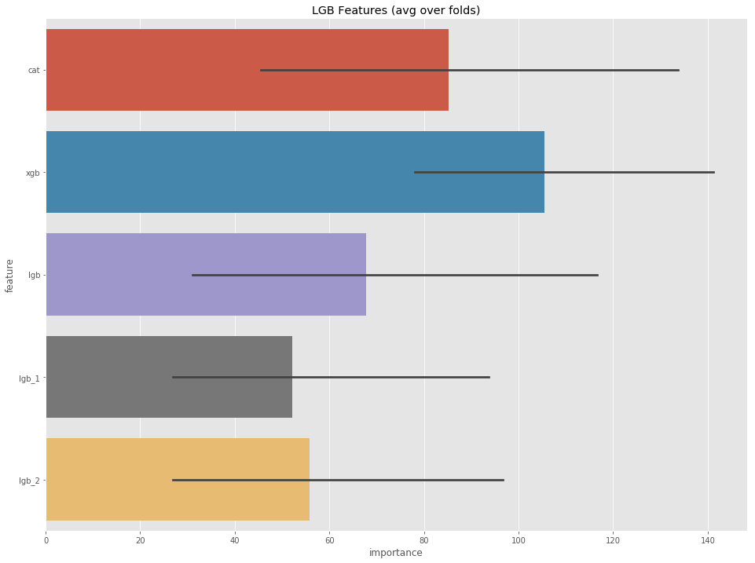

```python
params = {'num_leaves': 8,
         'min_data_in_leaf': 20,
         'objective': 'regression',
         'max_depth': 2,
         'learning_rate': 0.01,
         "boosting": "gbdt",
         "bagging_seed": 3472,
         "metric": 'rmse',
         "lambda_l1": 0.2,
         "verbosity": -1}
oof_lgb_stack, prediction_lgb_stack, _ = train_model(train_stack, test_stack, y, params=params, model_type='lgb', plot_feature_importance=True)
```

```python
model = linear_model.RidgeCV(alphas=(0.01, 0.1, 1.0, 10.0, 100.0), scoring='neg_mean_squared_error', cv=folds)
oof_rcv_stack, prediction_rcv_stack = train_model(train_stack.values, test_stack.values, y, params=None, model_type='sklearn', model=model)
```

```
Fold 0 started at Fri May  3 17:29:19 2019
Fold 1 started at Fri May  3 17:29:20 2019
Fold 2 started at Fri May  3 17:29:20 2019
Fold 3 started at Fri May  3 17:29:20 2019
Fold 4 started at Fri May  3 17:29:20 2019
CV mean score: 1.8405, std: 0.1695.
```

```python
sub = pd.read_csv('Layer_52.csv')
```